# INFSCI 2595 Fall 2022 Homework: 02

Assigned September 8, 2022; Due: September 15, 2022

ABHIBHA

Submission time: September 15, 2022 at 11:00PM EST

```r
knitr::opts_chunk$set(echo = TRUE)
```

#### Collaborators

Include the names of your collaborators here. Vishruth Reddy Siddharaj Oak

## Overview

This assignment is focused on fitting and comparing regression models. Your task is to fit 9 polynomial models from degree 1 (linear relationship) to degree 9 (a 9th degree polynomial). You will interpret behavior through analyzing the coefficient estimates and by visualizing predictions from the models. You must select the best performing model and you will do so several different ways. You will first consider performance on the training set alone, then use a single train/test split, and finally using 5-fold cross-validation.

You will work with 3 different data sets, but all 3 data sets were generated from the same **data generating process**. These 3 different versions of the data will allow you consider the influence of sample size (low vs high) and uncontrollable variation or noise (low vs high) on the model selection process.

**IMPORTANT**: You are working with 3 data sets in this assignment. This does not mean you must always have multiple “versions” of a data set to complete a machine learning application. This assignment is constructed so that you may experience the relationship between sample size and noise on the ability to learn and identify appropriate levels of complexity. The data in this assignment are synthetic data created specifically for this assignment.

**IMPORTANT**: The RMarkdown assumes you have downloaded the 3 data sets (CSV files) to the same directory you saved the template Rmarkdown file. If you do not have the 3 CSV files in the correct location, the data will not be loaded correctly.

### IMPORTANT!!!

Certain code chunks are created for you. Each code chunk has `eval=FALSE` set in the chunk options. You **MUST** change it to be `eval=TRUE` in order for the code chunks to be evaluated when rendering the document.

You are free to add more code chunks if you would like.

## Load packages

The `tidyverse` is loaded in for you in the code chunk below. The visualization package, `ggplot2`, and the data manipulation package, `dplyr`, are part of the “larger” `tidyverse`.

```r
library(tidyverse)
```

The `modelr` package is loaded in for you in the code chunk below. You may use functions from `modelr` to calculate performance metrics for your models.

```r
library(modelr)
```

This assignment also uses functions from the `coefplot` package and uses the major functions from the `caret` package. Those packages will be loaded when necessary later in the assignment.

## Problem 01

A data set is loaded for you in the code chunk below. The data are assigned to the `df_low_high` object. The naming convention of this variable represents that the data were generated with low sample size and high noise. Thus, you will begin your predictive modeling or *supervised learning* task with data that are known to be noisy.

```r
path_low_high <- 'hw02_lowsize_highnoise.csv'

df_low_high <- readr::read_csv(path_low_high, col_names = TRUE)
```

A glimpse of the data are provided for you below. The variable `x` is the input and the variable `y` is the response. Your task is to predict `y` as a function of `x` using various polynomial models. As stated before, the data in Problem 01 are the “noisy” data.

```r
df_low_high %>% glimpse()
```

```
## Rows: 40
## Columns: 2
## $ x <dbl> -0.11464944, 0.22502931, 0.37356406, -2.34241739, 1.15847408, 0.3443…
## $ y <dbl> 2.9964689, -0.9068521, -3.9404374, 5.0813180, -6.8506793, 2.5897728,…
```

### 1a)

It is always best to explore the data before fitting models. For this assignment, all you are required to do is visualize the relationship between the output and input with a scatter plot.

**Use ggplot2 to create a scatter plot between the input, `x`, and the response, `y`. The scatter plot is created with the `geom_point()` geom. Manually set the marker size to be 3 within the `geom_point()` geom.**

**Does the relationship between the input and response appear to be linear or non-linear?**  
The relationship seems non linear.

#### SOLUTION

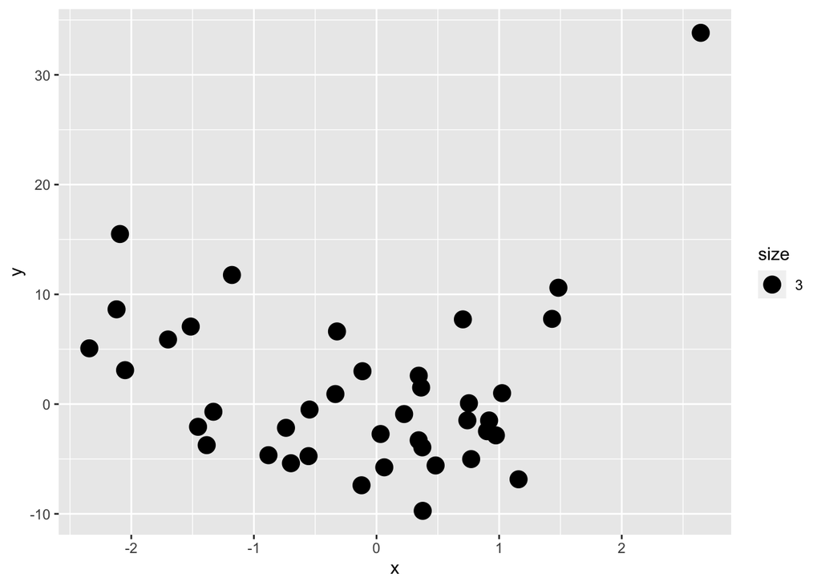

```r
### your code here
ggplot(data = df_low_high) +
  geom_point(mapping = aes(x = x, y = y, size = 3))
```

**Is the relationship linear or non-linear?**  
the relationship seems non linear.

### 1b)

It’s time fit the models! You must fit 9 models using the `lm()` function and the formula interface. You used both the `lm()` function and the formula interface in the previous assignment. However, this time you must specify the appropriate polynomial features. You are not allowed to use any functions to generate the polynomials. You **MUST** manually type each polynomial feature in the formulas!

**Complete the code chunks below by calling the `lm()` function with the appropriate formula and correctly specifying the `data` argument. The result are assigned to variable names defined for you in each of the code chunks. The variable names and the comment within each code chunk specifies the polynomial degree you should use.**

**You must use the complete data for fitting the models.**

#### SOLUTION

```r
### linear relationship (degree 1)
fit_lm_1 <- lm(y ~ x , data = df_low_high)
fit_lm_1 %>% summary()
```

```
##
## Call:
## lm(formula = y ~ x, data = df_low_high)
##
## Residuals:
##     Min      1Q  Median      3Q     Max
## -11.131  -4.855  -1.923   4.758  31.641
##
## Coefficients:
##             Estimate Std. Error t value Pr(>|t|)
## (Intercept)   1.2769     1.2606   1.013    0.318
## x             0.3444     1.0952   0.314    0.755
##
## Residual standard error: 7.918 on 38 degrees of freedom
## Multiple R-squared:  0.002596,   Adjusted R-squared:  -0.02365
## F-statistic: 0.0989 on 1 and 38 DF,  p-value: 0.7549
```

```r
### quadratic relationship (degree 2)
fit_lm_2 <- lm( y ~ x + I(x^2), data = df_low_high)
fit_lm_2 %>% summary()
```

```
##
## Call:
## lm(formula = y ~ x + I(x^2), data = df_low_high)
##
## Residuals:
##     Min      1Q  Median      3Q     Max
## -10.553  -3.726  -1.138   3.268  12.236
##
## Coefficients:
##             Estimate Std. Error t value Pr(>|t|)
## (Intercept)  -3.4617     1.0445  -3.314  0.00206 **
## x             1.8622     0.7406   2.515  0.01640 *
## I(x^2)        3.7308     0.5113   7.296 1.15e-08 ***
## ---
## Signif. codes:  0 '***' 0.001 '**' 0.01 '*' 0.05 '.' 0.1 ' ' 1
##
## Residual standard error: 5.139 on 37 degrees of freedom
## Multiple R-squared:  0.591,  Adjusted R-squared:  0.5689
## F-statistic: 26.73 on 2 and 37 DF,  p-value: 6.555e-08
```

```r
### cubic relationship (degree 3)
fit_lm_3 <- lm( y ~ x + I(x^2) + I(x^3), data = df_low_high)
fit_lm_3 %>% summary()
```

```
##
## Call:
## lm(formula = y ~ x + I(x^2) + I(x^3), data = df_low_high)
##
## Residuals:
##     Min      1Q  Median      3Q     Max
## -8.7999 -3.2010 -0.2738  2.6739 10.1297
##
## Coefficients:
##             Estimate Std. Error t value Pr(>|t|)
## (Intercept)  -2.9936     1.0003  -2.993  0.00497 **
## x            -0.8654     1.3212  -0.655  0.51665
## I(x^2)        3.5211     0.4882   7.212 1.73e-08 ***
## I(x^3)        0.7846     0.3231   2.429  0.02028 *
## ---
## Signif. codes:  0 '***' 0.001 '**' 0.01 '*' 0.05 '.' 0.1 ' ' 1
##
## Residual standard error: 4.829 on 36 degrees of freedom
## Multiple R-squared:  0.6486, Adjusted R-squared:  0.6193
## F-statistic: 22.15 on 3 and 36 DF,  p-value: 2.665e-08
```

```r
### degree 4
fit_lm_4 <- lm( y ~ x + I(x^2) + I(x^3) + I(x^4), data = df_low_high)
fit_lm_4 %>% summary()
```

```
##
## Call:
## lm(formula = y ~ x + I(x^2) + I(x^3) + I(x^4), data = df_low_high)
##
## Residuals:
##     Min      1Q  Median      3Q     Max
## -8.5243 -3.3671 -0.5129  2.9719 10.3697
##
## Coefficients:
##             Estimate Std. Error t value Pr(>|t|)
## (Intercept)  -2.7717     1.2620  -2.196   0.0348 *
## x            -0.8328     1.3429  -0.620   0.5392
## I(x^2)        3.0563     1.6518   1.850   0.0727 .
## I(x^3)        0.7460     0.3524   2.117   0.0415 *
## I(x^4)        0.0825     0.2797   0.295   0.7698
## ---
## Signif. codes:  0 '***' 0.001 '**' 0.01 '*' 0.05 '.' 0.1 ' ' 1
##
## Residual standard error: 4.891 on 35 degrees of freedom
## Multiple R-squared:  0.6495, Adjusted R-squared:  0.6094
## F-statistic: 16.21 on 4 and 35 DF,  p-value: 1.334e-07
```

```r
### degree 5
fit_lm_5 <- lm( y ~ x + I(x^2) + I(x^3) + I(x^4) + I(x^5), data = df_low_high)
fit_lm_5 %>% summary()
```

```
##
## Call:
## lm(formula = y ~ x + I(x^2) + I(x^3) + I(x^4) + I(x^5), data = df_low_high)
##
## Residuals:
##     Min      1Q  Median      3Q     Max
## -8.5438 -3.3928 -0.4862  2.8997 10.3591
##
## Coefficients:
##             Estimate Std. Error t value Pr(>|t|)
## (Intercept) -2.76706    1.28374  -2.155   0.0383 *
## x           -0.93701    2.47257  -0.379   0.7071
## I(x^2)       3.05965    1.67718   1.824   0.0769 .
## I(x^3)       0.84420    1.97737   0.427   0.6721
## I(x^4)       0.08651    0.29468   0.294   0.7709
## I(x^5)      -0.01386    0.27440  -0.051   0.9600
## ---
## Signif. codes:  0 '***' 0.001 '**' 0.01 '*' 0.05 '.' 0.1 ' ' 1
##
## Residual standard error: 4.962 on 34 degrees of freedom
## Multiple R-squared:  0.6495, Adjusted R-squared:  0.5979
## F-statistic:  12.6 on 5 and 34 DF,  p-value: 5.84e-07
```

```r
### degree 6
fit_lm_6 <- lm( y ~ x + I(x^2) + I(x^3) + I(x^4) + I(x^5) + I(x^6), data = df_low_high)
fit_lm_6 %>% summary()
```

```
##
## Call:
## lm(formula = y ~ x + I(x^2) + I(x^3) + I(x^4) + I(x^5) + I(x^6),
##     data = df_low_high)
##
## Residuals:
##     Min      1Q  Median      3Q     Max
## -7.8483 -3.1301 -0.3711  2.1496 12.0656
##
## Coefficients:
##             Estimate Std. Error t value Pr(>|t|)
## (Intercept) -1.43218    1.46480  -0.978   0.3353
## x           -1.54231    2.42736  -0.635   0.5296
## I(x^2)      -2.99550    3.84660  -0.779   0.4417
## I(x^3)       1.62112    1.97246   0.822   0.4170
## I(x^4)       3.78775    2.14902   1.763   0.0872 .
## I(x^5)      -0.00956    0.26660  -0.036   0.9716
## I(x^6)      -0.44929    0.25854  -1.738   0.0916 .
## ---
## Signif. codes:  0 '***' 0.001 '**' 0.01 '*' 0.05 '.' 0.1 ' ' 1
##
## Residual standard error: 4.821 on 33 degrees of freedom
## Multiple R-squared:  0.6789, Adjusted R-squared:  0.6205
## F-statistic: 11.63 on 6 and 33 DF,  p-value: 5.707e-07
```

```r
### degree 7
fit_lm_7 <- lm( y ~ x + I(x^2) + I(x^3) + I(x^4) + I(x^5) + I(x^6) + I(x^7), data = df_low_high)
fit_lm_7 %>% summary()
```

```
##
## Call:
## lm(formula = y ~ x + I(x^2) + I(x^3) + I(x^4) + I(x^5) + I(x^6) +
##     I(x^7), data = df_low_high)
##
## Residuals:
##     Min      1Q  Median      3Q     Max
## -7.6512 -3.0629 -0.2578  2.1243 11.9627
##
## Coefficients:
##             Estimate Std. Error t value Pr(>|t|)
## (Intercept) -1.34138    1.52158  -0.882    0.385
## x           -0.84579    3.52200  -0.240    0.812
## I(x^2)      -3.62807    4.52259  -0.802    0.428
## I(x^3)       0.25342    5.33467   0.048    0.962
## I(x^4)       4.20437    2.64963   1.587    0.122
## I(x^5)       0.62591    2.31359   0.271    0.788
## I(x^6)      -0.48743    0.29629  -1.645    0.110
## I(x^7)      -0.06828    0.24689  -0.277    0.784
##
## Residual standard error: 4.89 on 32 degrees of freedom
## Multiple R-squared:  0.6796, Adjusted R-squared:  0.6096
## F-statistic: 9.698 on 7 and 32 DF,  p-value: 2.004e-06
```

```r
### degree 8
fit_lm_8 <- lm( y ~ x + I(x^2) + I(x^3) + I(x^4) + I(x^5) + I(x^6) + I(x^7) + I(x^8), data = df_low_high)
fit_lm_8 %>% summary()
```

```
##
## Call:
## lm(formula = y ~ x + I(x^2) + I(x^3) + I(x^4) + I(x^5) + I(x^6) +
##     I(x^7) + I(x^8), data = df_low_high)
##
## Residuals:
##    Min     1Q Median     3Q    Max
## -8.141 -3.266 -0.171  2.308 11.026
##
## Coefficients:
##             Estimate Std. Error t value Pr(>|t|)
## (Intercept)  -2.1119     1.7524  -1.205    0.237
## x             1.4413     4.3606   0.331    0.743
## I(x^2)        2.3291     8.0561   0.289    0.774
## I(x^3)       -5.8503     8.6696  -0.675    0.505
## I(x^4)       -3.3330     8.8325  -0.377    0.708
## I(x^5)        3.7144     4.1591   0.893    0.379
## I(x^6)        2.4270     3.2704   0.742    0.464
## I(x^7)       -0.3726     0.4207  -0.886    0.383
## I(x^8)       -0.2870     0.3207  -0.895    0.378
##
## Residual standard error: 4.906 on 31 degrees of freedom
## Multiple R-squared:  0.6877, Adjusted R-squared:  0.6071
## F-statistic: 8.533 on 8 and 31 DF,  p-value: 4.61e-06
```

```r
### degree 9
fit_lm_9 <- lm( y ~ x + I(x^2) + I(x^3) + I(x^4) + I(x^5) + I(x^6) + I(x^7) + I(x^8)+I(x^9) , data = df_low_high)
fit_lm_9 %>% summary()
```

```
##
## Call:
## lm(formula = y ~ x + I(x^2) + I(x^3) + I(x^4) + I(x^5) + I(x^6) +
##     I(x^7) + I(x^8) + I(x^9), data = df_low_high)
##
## Residuals:
##     Min      1Q  Median      3Q     Max
## -7.9633 -3.6310 -0.1837  1.7409 12.0952
##
## Coefficients:
##             Estimate Std. Error t value Pr(>|t|)
## (Intercept)  -2.5595     1.8671  -1.371    0.181
## x            -0.3716     5.0349  -0.074    0.942
## I(x^2)        7.8702    11.0637   0.711    0.482
## I(x^3)        1.6160    13.3764   0.121    0.905
## I(x^4)      -12.5569    15.3569  -0.818    0.420
## I(x^5)       -4.3762    11.7508  -0.372    0.712
## I(x^6)        6.4072     6.3265   1.013    0.319
## I(x^7)        2.5762     4.0238   0.640    0.527
## I(x^8)       -0.6699     0.6118  -1.095    0.282
## I(x^9)       -0.2825     0.3833  -0.737    0.467
##
## Residual standard error: 4.942 on 30 degrees of freedom
## Multiple R-squared:  0.6933, Adjusted R-squared:  0.6012
## F-statistic: 7.534 on 9 and 30 DF,  p-value: 1.117e-05
```

### 1c)

You fit 9 regression models, it’s time to pick the best one! You will initially make your selection based on the training set performance.

**Calculate the training set RMSE for each model. It is up to you as to how to organize the RMSE values and display the results. Bare minimum, you must display the RMSE for each model. You are only allowed to use functions from lecture.**

#### SOLUTION

```r
### add as many code chunks as necessary
modelr :: rmse(fit_lm_1, df_low_high)
```

```
## [1] 7.717771
```

```r
modelr :: rmse(fit_lm_2, df_low_high)
```

```
## [1] 4.942079
```

```r
modelr :: rmse(fit_lm_3, df_low_high)
```

```
## [1] 4.581047
```

```r
modelr :: rmse(fit_lm_4, df_low_high)
```

```
## [1] 4.575364
```

```r
modelr :: rmse(fit_lm_5, df_low_high)
```

```
## [1] 4.575193
```

```r
modelr :: rmse(fit_lm_6, df_low_high)
```

```
## [1] 4.379204
```

```r
modelr :: rmse(fit_lm_7, df_low_high)
```

```
## [1] 4.37398
```

```r
modelr :: rmse(fit_lm_8, df_low_high)
```

```
## [1] 4.31856
```

```r
modelr :: rmse(fit_lm_9, df_low_high)
```

```
## [1] 4.279992
```

### 1d)

There are many different performance metrics we can use to compare models. For this problem, we will consider R-squared in addition to the RMSE.

**Calculate the training set R-squared for each model. It is up to you as to how to organize the R-squared values and display the results. Bare minimum, you must display the R-squared for each model. You are only allowed to use functions from lecture.**

#### SOLUTION

```r
### add as many code chunks as necessary
modelr :: rsquare(fit_lm_1, df_low_high)
```

```
## [1] 0.002595816
```

```r
modelr :: rsquare(fit_lm_2, df_low_high)
```

```
## [1] 0.5910155
```

```r
modelr :: rsquare(fit_lm_3, df_low_high)
```

```
## [1] 0.6485876
```

```r
modelr :: rsquare(fit_lm_4, df_low_high)
```

```
## [1] 0.649459
```

```r
modelr :: rsquare(fit_lm_5, df_low_high)
```

```
## [1] 0.6494853
```

```r
modelr :: rsquare(fit_lm_6, df_low_high)
```

```
## [1] 0.6788723
```

```r
modelr :: rsquare(fit_lm_7, df_low_high)
```

```
## [1] 0.679638
```

```r
modelr :: rsquare(fit_lm_8, df_low_high)
```

```
## [1] 0.6877048
```

```r
modelr :: rsquare(fit_lm_9, df_low_high)
```

```
## [1] 0.6932579
```

### 1e)

**Which model is the best according to the training set performance metrics? Why did you make the selection that you did? Do the two performance metrics agree on the best model?**  
According to the training set performance model9 performs the best as it has the lowest rmse and highest r squared value.

```r
### add as many code chunks as necessary

viz_trend_new <- as.vector(predict(fit_lm_9, newdata = as.vector(df_low_high['x']) ))
viz_trend_new
```

```
##  [1] -2.4179796 -2.2600150 -1.7724407  5.4631863 -2.1960701 -1.8738661
##  [7] -1.2500993  5.8564184  8.8418282 -1.3547456 -1.0270035 -1.0478170
## [13] -1.4067229 -2.2500305 -1.8061029  1.9600412 -2.5631348 -0.7274964
## [19] 33.8315525 -1.9284120 -2.5513049  1.1234042 -0.7645326 -1.7901886
## [25] -1.7426150  0.5972675 -1.8762552 10.6937162  9.0723302 -0.6888493
## [31] -2.4171967 -1.7614185 -1.4277511 -1.3221389  9.2834029 -0.3297756
## [37] -2.0080470  6.6731834 -2.4020270  2.7922215
```

#### SOLUTION

What do you think?

### 1f)

Let’s dive deeper into a few of the models. You will visualize the coefficient summaries for three models to examine the number of statistically significant features and to get an idea of the uncertainty on the coefficients. Regardless of your answer to Problem 1e), you must examine the coefficients for the quadratic model (degree 2), the 6th degree model, and the 9th degree model.

You used the `coefplot()` function from the `coefplot` package to visualize model coefficient summaries in the previous assignment. You could call `coefplot::coefplot()` three different times, one for each model. However, the `coefplot` package has a useful “helper” function dedicated to visualizing the coefficients across multiple models. This function is named `coefplot::multiplot()`. The `coefplot::multiplot()` syntax is similar to `coefplot::coefplot()`. You pass in the model objects as arguments to the function. You must separate each model with a comman, `,`, within the function call. The `coefplot::multiplot()` function takes care of everything for you.

**Visualize the coefficient summaries for the quadratic (degree 2), 6th degree, and 9th degree polynomial models using the `coefplot::multiplot()` function.**

**You do NOT need to load the `coefplot` package. The `::` operator allows accessing the function `multiplot()` from within the `coefplot` library.**

#### SOLUTION

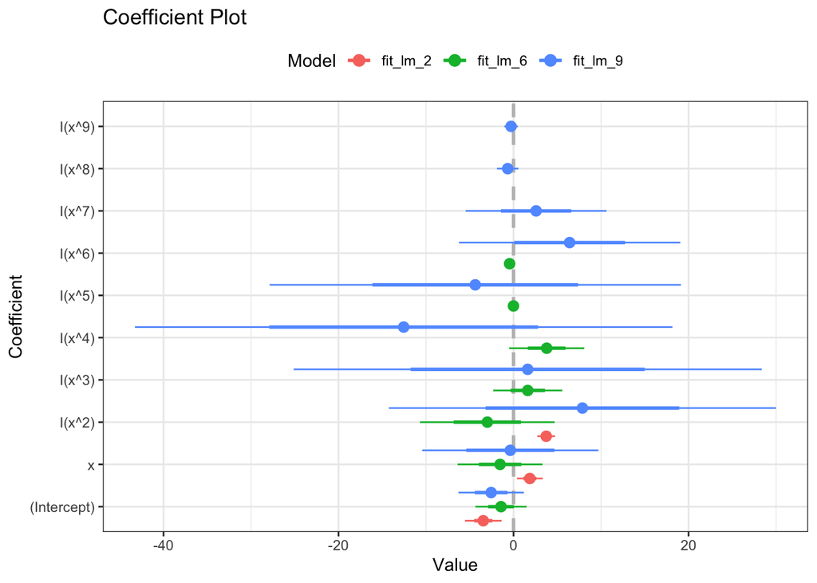

```r
### add your code here
coefplot::multiplot(fit_lm_2, fit_lm_6, fit_lm_9) +
theme_bw() +
theme(legend.position = 'top')
```

### 1g)

Some of the coefficients are present in all three models displayed in the figure from Problem 1f), while a few of the coefficients are only present in one of the models. Let’s look closely at the previous figure to try and interpret the model behavior.

**Are the coefficient estimates similar for those coefficients present in at least 2 of the models visualized in the previous figure?**  
No the coefficient estimates are not similar for x and x^2 (i.e the common coefficients) for model 2 and 6. The uncertainty is higher in 6 as compared to 2.

**Is the level or amount of uncertainty associated with the coefficients consistent across the three models?**  
No the coefficient estimates are not consistent across the three models. There is more uncertainty associated with the coefficients of x and x^2 for models fir_lm_6 and fit_lm_9 as compared to fit_lm_2

#### SOLUTION

What do you think?

## Problem 02

We discussed in lecture the importance of visualizing predictive model trends. This is an important and useful way of interpreting model behavior because it allows us to “see” what the model “thinks” happens at input values **not** present in the original training set. Creating such visualizations requires creating a new data set. Such data sets can require careful planning when there are dozens to hundreds of inputs. However, our present application has a single input and thus it is easy to define a meaningful *input grid* to support visualizing trends.

### 2a)

You must create the input grid to support visualization by defining a variable `x` within a data.frame (tibble) that consists of 201 evenly spaced points between the training set minimum and maximum values.

**The code chunk below is started for you. The `tibble::tibble()` function defines a tibble object. The data variable `x` is assigned within that tibble. You must complete that line of code by using an appropriate function which creates a sequence of values from a lower bound to an upper bound. You must use 201 evenly spaced points.**

**The lower bound must equal the input training set minimum value and the upper bound must equal the input training set maximum value.**

*HINT*: The lecture slides shows how to create this kind of object…

#### SOLUTION

```r
max(df_low_high$x, na.rm = TRUE)
```

```
## [1] 2.644329
```

```r
min(df_low_high$x, na.rm = TRUE)
```

```
## [1] -2.342417
```

```r
input_viz <- tibble::tibble(
  x = seq(-2.342417, 2.644329, length.out = 201)
)
str(input_viz)
```

```
## tibble [201 × 1] (S3: tbl_df/tbl/data.frame)
##  $ x: num [1:201] -2.34 -2.32 -2.29 -2.27 -2.24 ...
```

If you created `input_viz` correctly, it should have 201 rows. The code chunk below checks the number of rows for you.

```r
input_viz %>% nrow()
```

```
## [1] 201
```

### 2b)

You must now make predictions for each model! In lecture, we discussed the importance including two types of uncertainty when we make predictions. However, since we are at the beginning of the semester, you are only responsible for making predictions of the **trend** or **average response**. Your returned predictions will therefore consist of numeric vectors.

**Complete the code chunks below by calling the appropriate function for making predictions for each model. The returned predictions are assigned must be assigned to the variables named in the code chunk below. The comments and the variable names specify which model should be used.**

*HINT*: Pay close attention to which data set you use when making the predictions…

#### SOLUTION

```r
### linear relationship (degree 1) predictions
viz_trend_1 <- as.vector(predict(fit_lm_1, newdata = input_viz))
viz_trend_1
```

```
##   [1] 0.4700901 0.4786780 0.4872659 0.4958538 0.5044417 0.5130296 0.5216174
##   [8] 0.5302053 0.5387932 0.5473811 0.5559690 0.5645569 0.5731448 0.5817326
##  [15] 0.5903205 0.5989084 0.6074963 0.6160842 0.6246721 0.6332599 0.6418478
##  [22] 0.6504357 0.6590236 0.6676115 0.6761994 0.6847873 0.6933751 0.7019630
##  [29] 0.7105509 0.7191388 0.7277267 0.7363146 0.7449025 0.7534903 0.7620782
##  [36] 0.7706661 0.7792540 0.7878419 0.7964298 0.8050176 0.8136055 0.8221934
##  [43] 0.8307813 0.8393692 0.8479571 0.8565450 0.8651328 0.8737207 0.8823086
##  [50] 0.8908965 0.8994844 0.9080723 0.9166601 0.9252480 0.9338359 0.9424238
##  [57] 0.9510117 0.9595996 0.9681875 0.9767753 0.9853632 0.9939511 1.0025390
##  [64] 1.0111269 1.0197148 1.0283026 1.0368905 1.0454784 1.0540663 1.0626542
##  [71] 1.0712421 1.0798300 1.0884178 1.0970057 1.1055936 1.1141815 1.1227694
##  [78] 1.1313573 1.1399452 1.1485330 1.1571209 1.1657088 1.1742967 1.1828846
##  [85] 1.1914725 1.2000603 1.2086482 1.2172361 1.2258240 1.2344119 1.2429998
##  [92] 1.2515877 1.2601755 1.2687634 1.2773513 1.2859392 1.2945271 1.3031150
##  [99] 1.3117028 1.3202907 1.3288786 1.3374665 1.3460544 1.3546423 1.3632302
## [106] 1.3718180 1.3804059 1.3889938 1.3975817 1.4061696 1.4147575 1.4233453
## [113] 1.4319332 1.4405211 1.4491090 1.4576969 1.4662848 1.4748727 1.4834605
## [120] 1.4920484 1.5006363 1.5092242 1.5178121 1.5264000 1.5349879 1.5435757
## [127] 1.5521636 1.5607515 1.5693394 1.5779273 1.5865152 1.5951030 1.6036909
## [134] 1.6122788 1.6208667 1.6294546 1.6380425 1.6466304 1.6552182 1.6638061
## [141] 1.6723940 1.6809819 1.6895698 1.6981577 1.7067455 1.7153334 1.7239213
## [148] 1.7325092 1.7410971 1.7496850 1.7582729 1.7668607 1.7754486 1.7840365
## [155] 1.7926244 1.8012123 1.8098002 1.8183880 1.8269759 1.8355638 1.8441517
## [162] 1.8527396 1.8613275 1.8699154 1.8785032 1.8870911 1.8956790 1.9042669
## [169] 1.9128548 1.9214427 1.9300306 1.9386184 1.9472063 1.9557942 1.9643821
## [176] 1.9729700 1.9815579 1.9901457 1.9987336 2.0073215 2.0159094 2.0244973
## [183] 2.0330852 2.0416731 2.0502609 2.0588488 2.0674367 2.0760246 2.0846125
## [190] 2.0932004 2.1017882 2.1103761 2.1189640 2.1275519 2.1361398 2.1447277
## [197] 2.1533156 2.1619034 2.1704913 2.1790792 2.1876671
```

```r
### quadratic relationship (degree 2) predictions
viz_trend_2 <- as.vector(predict(fit_lm_2, newdata = input_viz))
viz_trend_2
```

```
##   [1] 12.646698555 12.259657772 11.877255742 11.499492466 11.126367945
##   [6] 10.757882177 10.394035163 10.034826904  9.680257398  9.330326647
##  [11]  8.985034650  8.644381406  8.308366917  7.976991182  7.650254201
##  [16]  7.328155973  7.010696500  6.697875781  6.389693816  6.086150605
##  [21]  5.787246148  5.492980445  5.203353496  4.918365301  4.638015861
##  [26]  4.362305174  4.091233241  3.824800063  3.563005638  3.305849967
##  [31]  3.053333051  2.805454888  2.562215480  2.323614825  2.089652925
##  [36]  1.860329779  1.635645386  1.415599748  1.200192864  0.989424734
##  [41]  0.783295357  0.581804735  0.384952867  0.192739753  0.005165393
##  [46] -0.177770213 -0.356067065 -0.529725163 -0.698744506 -0.863125096
##  [51] -1.022866932 -1.177970014 -1.328434341 -1.474259915 -1.615446734
##  [56] -1.751994800 -1.883904111 -2.011174669 -2.133806472 -2.251799522
##  [61] -2.365153817 -2.473869358 -2.577946146 -2.677384179 -2.772183458
##  [66] -2.862343983 -2.947865754 -3.028748771 -3.104993034 -3.176598543
##  [71] -3.243565298 -3.305893299 -3.363582546 -3.416633039 -3.465044777
```

[output cut: 26 more lines]

```r
### cubic relationship (degree 3) predictions
viz_trend_3 <- as.vector(predict(fit_lm_3, newdata = input_viz))
viz_trend_3
```

```
##   [1]  8.26941768  8.15732960  8.04283715  7.92601333  7.80693110  7.68566343
##   [7]  7.56228330  7.43686368  7.30947753  7.18019784  7.04909757  6.91624970
##  [13]  6.78172720  6.64560303  6.50795018  6.36884162  6.22835031  6.08654923
##  [19]  5.94351135  5.79930965  5.65401709  5.50770665  5.36045130  5.21232402
##  [25]  5.06339777  4.91374552  4.76344025  4.61255494  4.46116255  4.30933605
##  [31]  4.15714842  4.00467263  3.85198166  3.69914847  3.54624603  3.39334732
##  [37]  3.24052531  3.08785298  2.93540329  2.78324922  2.63146374  2.48011982
##  [43]  2.32929043  2.17904855  2.02946715  1.88061919  1.73257766  1.58541553
##  [49]  1.43920576  1.29402133  1.14993521  1.00702038  0.86534980  0.72499644
##  [55]  0.58603329  0.44853331  0.31256948  0.17821476  0.04554213 -0.08537544
##  [61] -0.21446498 -0.34165351 -0.46686807 -0.59003567 -0.71108336 -0.82993815
##  [67] -0.94652707 -1.06077716 -1.17261543 -1.28196893 -1.38876466 -1.49292968
##  [73] -1.59439099 -1.69307563 -1.78891063 -1.88182301 -1.97173980 -2.05858804
##  [79] -2.14229474 -2.22278694 -2.29999166 -2.37383593 -2.44424679 -2.51115125
##  [85] -2.57447634 -2.63414910 -2.69009655 -2.74224571 -2.79052362 -2.83485731
```

[output cut: 19 more lines]

```r
### degree 4
viz_trend_4 <- as.vector(predict(fit_lm_4, newdata = input_viz))
viz_trend_4
```

```
##   [1]  8.84429225  8.66727761  8.49091982  8.31521752  8.14017012  7.96577779
##   [7]  7.79204145  7.61896282  7.44654435  7.27478927  7.10370159  6.93328606
##  [13]  6.76354820  6.59449432  6.42613146  6.25846745  6.09151087  5.92527108
##  [19]  5.75975819  5.59498309  5.43095743  5.26769361  5.10520482  4.94350499
##  [25]  4.78260885  4.62253186  4.46329025  4.30490105  4.14738201  3.99075167
##  [31]  3.83502933  3.68023506  3.52638968  3.37351480  3.22163277  3.07076672
##  [37]  2.92094054  2.77217890  2.62450720  2.47795164  2.33253916  2.18829750
##  [43]  2.04525513  1.90344130  1.76288601  1.62362006  1.48567499  1.34908310
##  [49]  1.21387746  1.08009193  0.94776110  0.81692034  0.68760578  0.55985434
##  [55]  0.43370367  0.30919220  0.18635914  0.06524443 -0.05411118 -0.17166621
##  [61] -0.28737841 -0.40120474 -0.51310143 -0.62302391 -0.73092688 -0.83676424
##  [67] -0.94048916 -1.04205401 -1.14141042 -1.23850924 -1.33330056 -1.42573372
##  [73] -1.51575726 -1.60331899 -1.68836593 -1.77084435 -1.85069974 -1.92787685
##  [79] -2.00231964 -2.07397131 -2.14277430 -2.20867029 -2.27160018 -2.33150412
##  [85] -2.38832148 -2.44199088 -2.49245015 -2.53963640 -2.58348592 -2.62393427
```

[output cut: 19 more lines]

```r
### degree 5
viz_trend_5 <- as.vector(predict(fit_lm_5, newdata = input_viz))
viz_trend_5
```

```
##   [1]  8.94743093  8.75132634  8.55733936  8.36540585  8.17546393  7.98745399
##   [7]  7.80131865  7.61700278  7.43445345  7.25361991  7.07445362  6.89690819
##  [13]  6.72093937  6.54650506  6.37356525  6.20208205  6.03201964  5.86334429
##  [19]  5.69602430  5.53003002  5.36533380  5.20191000  5.03973500  4.87878710
##  [25]  4.71904659  4.56049568  4.40311853  4.24690118  4.09183157  3.93789952
##  [31]  3.78509671  3.63341664  3.48285469  3.33340798  3.18507550  3.03785795
##  [37]  2.89175785  2.74677942  2.60292865  2.46021323  2.31864254  2.17822765
##  [43]  2.03898130  1.90091787  1.76405340  1.62840552  1.49399349  1.36083812
##  [49]  1.22896183  1.09838856  0.96914383  0.84125464  0.71474953  0.58965851
##  [55]  0.46601307  0.34384616  0.22319217  0.10408693 -0.01343235 -0.12932702
##  [61] -0.24355709 -0.35608120 -0.46685664 -0.57583935 -0.68298399 -0.78824389
##  [67] -0.89157113 -0.99291650 -1.09222954 -1.18945857 -1.28455068 -1.37745176
##  [73] -1.46810651 -1.55645848 -1.64245003 -1.72602242 -1.80711577 -1.88566908
##  [79] -1.96162028 -2.03490623 -2.10546271 -2.17322448 -2.23812526 -2.30009776
##  [85] -2.35907371 -2.41498384 -2.46775795 -2.51732485 -2.56361247 -2.60654778
```

[output cut: 19 more lines]

```r
### degree 6
viz_trend_6 <- as.vector(predict(fit_lm_6, newdata = input_viz))
viz_trend_6
```

```
##   [1]  5.39944851  6.16955592  6.83343662  7.39818205  7.87059125  8.25717794
##   [7]  8.56417750  8.79755399  8.96300692  9.06597812  9.11165841  9.10499422
##  [13]  9.05069415  8.95323548  8.81687051  8.64563292  8.44334401  8.21361883
##  [19]  7.95987231  7.68532525  7.39301023  7.08577752  6.76630079  6.43708284
##  [25]  6.10046123  5.75861379  5.41356414  5.06718700  4.72121357  4.37723671
##  [31]  4.03671613  3.70098345  3.37124719  3.04859773  2.73401207  2.42835870
##  [37]  2.13240221  1.84680793  1.57214645  1.30889809  1.05745728  0.81813681
##  [43]  0.59117212  0.37672541  0.17488967 -0.01430725 -0.19089880 -0.35497588
##  [49] -0.50668306 -0.64621494 -0.77381252 -0.88975970 -0.99437983 -1.08803234
##  [55] -1.17110944 -1.24403295 -1.30725112 -1.36123560 -1.40647846 -1.44348930
##  [61] -1.47279240 -1.49492400 -1.51042963 -1.51986152 -1.52377606 -1.52273144
##  [67] -1.51728522 -1.50799207 -1.49540161 -1.48005624 -1.46248912 -1.44322219
##  [73] -1.42276429 -1.40160935 -1.38023465 -1.35909918 -1.33864204 -1.31928092
##  [79] -1.30141076 -1.28540231 -1.27160092 -1.26032533 -1.25186656 -1.24648687
##  [85] -1.24441885 -1.24586444 -1.25099426 -1.25994676 -1.27282768 -1.28970940
```

[output cut: 19 more lines]

```r
### degree 7
viz_trend_7 <- as.vector(predict(fit_lm_7, newdata = input_viz))
viz_trend_7
```

```
##   [1]  5.81582274  6.41562035  6.93725471  7.38506643  7.76327922  8.07599975
##   [7]  8.32721751  8.52080488  8.66051722  8.74999309  8.79275459  8.79220768
##  [13]  8.75164277  8.67423525  8.56304615  8.42102292  8.25100028  8.05570107
##  [19]  7.83773731  7.59961126  7.34371652  7.07233931  6.78765971  6.49175306
##  [25]  6.18659133  5.87404465  5.55588283  5.23377698  4.90930119  4.58393421
##  [31]  4.25906127  3.93597589  3.61588174  3.29989459  2.98904426  2.68427665
##  [37]  2.38645577  2.09636587  1.81471351  1.54212982  1.27917258  1.02632857
##  [43]  0.78401573  0.55258550  0.33232513  0.12345998 -0.07384408 -0.25947836
##  [49] -0.43338888 -0.59557405 -0.74608218 -0.88500911 -1.01249574 -1.12872560
##  [55] -1.23392242 -1.32834766 -1.41229806 -1.48610321 -1.55012311 -1.60474572
##  [61] -1.65038455 -1.68747621 -1.71647806 -1.73786575 -1.75213092 -1.75977877
##  [67] -1.76132579 -1.75729741 -1.74822572 -1.73464721 -1.71710053 -1.69612431
##  [73] -1.67225497 -1.64602459 -1.61795882 -1.58857482 -1.55837923 -1.52786623
##  [79] -1.49751557 -1.46779073 -1.43913704 -1.41197995 -1.38672328 -1.36374754
##  [85] -1.34340834 -1.32603483 -1.31192817 -1.30136016 -1.29457186 -1.29177228
```

[output cut: 19 more lines]

```r
### degree 8
viz_trend_8 <- as.vector(predict(fit_lm_8, newdata = input_viz))
viz_trend_8
```

```
##   [1]  5.15150944  6.39836306  7.39820724  8.17946608  8.76822151  9.18835248
##   [7]  9.46166846  9.60803736  9.64550809  9.59042773  9.45755372  9.26016089
##  [13]  9.01014374  8.71811398  8.39349339  8.04460236  7.67874394  7.30228384
##  [19]  6.92072621  6.53878557  6.16045484  5.78906972  5.42736942  5.07755391
##  [25]  4.74133792  4.42000155  4.11443782  3.82519720  3.55252925  3.29642136
##  [31]  3.05663489  2.83273866  2.62413996  2.43011316  2.24982602  2.08236383
##  [37]  1.92675136  1.78197293  1.64699043  1.52075962  1.40224456  1.29043053
##  [43]  1.18433526  1.08301873  0.98559154  0.89122200  0.79914185  0.70865097
##  [49]  0.61912086  0.52999714  0.44080107  0.35113026  0.26065843  0.16913454
##  [55]  0.07638115 -0.01770784 -0.11317000 -0.20997765 -0.30804170 -0.40721580
##  [61] -0.50730086 -0.60804988 -0.70917297 -0.81034265 -0.91119922 -1.01135627
##  [67] -1.11040623 -1.20792599 -1.30348242 -1.39663789 -1.48695569 -1.57400527
##  [73] -1.65736739 -1.73663903 -1.81143809 -1.88140784 -1.94622110 -2.00558408
##  [79] -2.05923997 -2.10697216 -2.14860703 -2.18401646 -2.21311988 -2.23588596
##  [85] -2.25233384 -2.26253394 -2.26660831 -2.26473063 -2.25712562 -2.24406809
```

[output cut: 19 more lines]

```r
### degree 9
viz_trend_9 <- as.vector(predict(fit_lm_9, newdata = input_viz))
viz_trend_9
```

```
##   [1]   5.46319143   5.82566819   6.23567807   6.66923347   7.10620242
##   [6]   7.52992885   7.92687810   8.28630647   8.59995389   8.86175846
##  [11]   9.06759195   9.21501529   9.30305289   9.33198511   9.30315774
##  [16]   9.21880772   9.08190426   8.89600437   8.66512223   8.39361138
##  [21]   8.08605920   7.74719272   7.38179523   6.99463302   6.59039136
##  [26]   6.17361945   5.74868336   5.31972670   4.89063819   4.46502577
##  [31]   4.04619666   3.63714291   3.24053182   2.85870106   2.49365776
##  [36]   2.14708130   1.82032945   1.51444734   1.23017904   0.96798130
##  [41]   0.72803924   0.51028361   0.31440931   0.13989503  -0.01397642
##  [46]  -0.14809712  -0.26351287  -0.36140173  -0.44305275  -0.50984490
##  [51]  -0.56322640  -0.60469456  -0.63577641  -0.65801001  -0.67292674
##  [56]  -0.68203459  -0.68680247  -0.68864583  -0.68891329  -0.68887474
##  [61]  -0.68971061  -0.69250253  -0.69822536  -0.70774054  -0.72179085
##  [66]  -0.74099648  -0.76585252  -0.79672768  -0.83386434  -0.87737991
##  [71]  -0.92726923  -0.98340835  -1.04555919  -1.11337540  -1.18640908
```

[output cut: 26 more lines]

### 2c)

Let’s manipulate the data before visualizing the predictions. This way we can organize the data into a “tidy format” to support proper visualization strategies.

The code chunk below is started for you. The `input_viz` object is piped into the `mutate()` function where two data variables are assigned, `pred_trend` and `poly_degree`. The predictions made in the previous question will be assigned to the `pred_trend` data variable. You will manually assign the `poly_degree` variable for the model which made the predictions. Please note that you only need to provide a scalar value for `poly_degree`. The `mutate()` function will make sure to broadcast that scalar value to all rows in the tibble.

Let’s start by compiling the `df_viz_1` object which stores the prediction input and predicted trend for the linear relationship model.

**Complete the code chunk below by assigning the linear relationship model’s predicted trend to the `pred_trend` data variable and assign the value `1` to the `poly_degree` data variable. The `df_viz_1` object is assigned for you and a glimpse is displayed to the screen. If you created the `df_viz_1` object correctly it should consist of 3 variable (columns) and 201 rows.**

#### SOLUTION

```r
df_viz_1 <- input_viz %>%
  mutate(pred_trend =viz_trend_1 ,
         poly_degree = 1)

df_viz_1 %>% glimpse()
```

```
## Rows: 201
## Columns: 3
## $ x           <dbl> -2.342417, -2.317483, -2.292550, -2.267616, -2.242682, -2.…
## $ pred_trend  <dbl> 0.4700901, 0.4786780, 0.4872659, 0.4958538, 0.5044417, 0.5…
## $ poly_degree <dbl> 1, 1, 1, 1, 1, 1, 1, 1, 1, 1, 1, 1, 1, 1, 1, 1, 1, 1, 1, 1…
```

### 2d)

You can now visualize the predicted trend for the linear relationship! You will use a line to visualize the trend so that way the smooth sequential trend is visualized.

**Pass the `df_viz_1` tibble into `ggplot()`. Map the `x` aesthetic to the `x` variable within the “parent” `ggplot()` call. Add the `geom_line()` layer and map the `y` aesthetic to the `pred_trend` variable within the `geom_line()` geom. Thus, you should NOT map both `x` and `y` aesthetics in the “parent” `ggplot()` call.**

#### SOLUTION

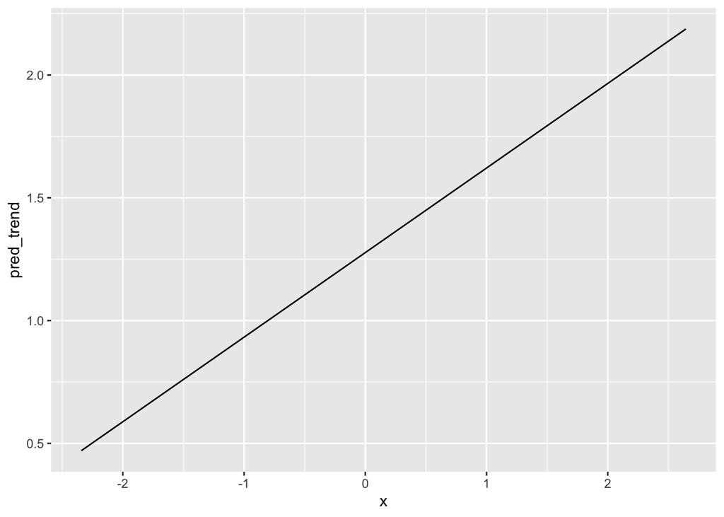

```r
### add your code here
ggplot(data = df_viz_1, mapping = aes(x)) + geom_line( mapping = aes(y= pred_trend))
```

### 2e)

Let’s add further context to the predictive trend visualization by overlaying the original training set scatter plot. We thus need to create a graphic that uses two different data sets. This is ok! Each `geom_*` function has a `data` argument. By default, the `geom_*` function, (such as `geom_point()` or `geom_line()`) inherits the `data` provided to the “parent” `ggplot()` call. However, we can override this behavior by manually specifying a new data set to the `data` argument within the `geom_*` layer! This effectively allows us to show behavior coming from multiple data sets.

**Visualize the predicted trend associated with the linear relationship again. Pass the `df_viz_1` tibble into `ggplot()`. Map the `x` aesthetic to the `x` variable within the “parent” `ggplot()` call. However, before adding `geom_line()` add `geom_point()` where you specify the `data` argument in `geom_point()` to be `df_low_high`. Map the `y` aesthetic within `geom_point()` to the `y` variable and manually assign the marker `shape` to 0 and the marker `color` to `'red'`. Add the `geom_line()` layer where you map the `y` aesthetic to the `pred_trend` variable and manually assign the line `size` to 1.**

Your completed graphic should display the original training set as red open squares and the predicted trend as a black line.

#### SOLUTION

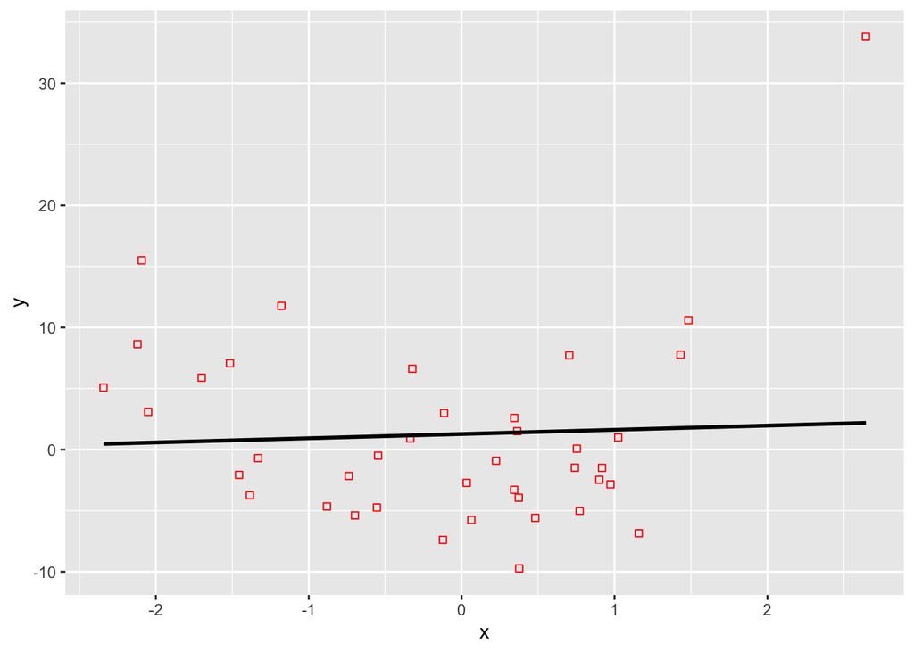

```r
ggplot(data = df_viz_1, mapping = aes(x)) + geom_point(data = df_low_high, mapping = aes(y= y), shape = 0, color = 'red') + geom_line( mapping = aes(y= pred_trend), size=1)
```

```r
### add your code here
```

### 2f)

You visualized the predicted trend associated with 1 model! You must now repeat these steps for the remaining 8 models. You will start by properly organizing the predictive trends from the other 8 models into their own tibbles.

**Complete the code chunks below. You must assign the predictive trends to the `pred_trend` data variable and assign the correct value for the `poly_degree` data variable. The comments and variable names state the models associated with each code chunk.**

**NOTE**: This is NOT the most efficient way to properly organize the predictions. More streamlined approaches make use of **functional programming** techniques to create one properly organized and “tidy” data set in just a few lines of code. We will learn how to do that later in the semester. For now though, we will go through the tedious way!

#### SOLUTION

```r
### quadratic relationship (degree 2)
df_viz_2 <- input_viz %>%
  mutate(pred_trend =viz_trend_2 ,
         poly_degree = 2)

df_viz_2 %>% glimpse()
```

```
## Rows: 201
## Columns: 3
## $ x           <dbl> -2.342417, -2.317483, -2.292550, -2.267616, -2.242682, -2.…
## $ pred_trend  <dbl> 12.646699, 12.259658, 11.877256, 11.499492, 11.126368, 10.…
## $ poly_degree <dbl> 2, 2, 2, 2, 2, 2, 2, 2, 2, 2, 2, 2, 2, 2, 2, 2, 2, 2, 2, 2…
```

```r
### cubic relationship (degree 3)
df_viz_3 <- input_viz %>%
  mutate(pred_trend =viz_trend_3 ,
         poly_degree = 3)

df_viz_3 %>% glimpse()
```

```
## Rows: 201
## Columns: 3
## $ x           <dbl> -2.342417, -2.317483, -2.292550, -2.267616, -2.242682, -2.…
## $ pred_trend  <dbl> 8.269418, 8.157330, 8.042837, 7.926013, 7.806931, 7.685663…
## $ poly_degree <dbl> 3, 3, 3, 3, 3, 3, 3, 3, 3, 3, 3, 3, 3, 3, 3, 3, 3, 3, 3, 3…
```

```r
### degree 4
df_viz_4 <- input_viz %>%
  mutate(pred_trend =viz_trend_4 ,
         poly_degree = 4)

df_viz_4 %>% glimpse()
```

```
## Rows: 201
## Columns: 3
## $ x           <dbl> -2.342417, -2.317483, -2.292550, -2.267616, -2.242682, -2.…
## $ pred_trend  <dbl> 8.844292, 8.667278, 8.490920, 8.315218, 8.140170, 7.965778…
## $ poly_degree <dbl> 4, 4, 4, 4, 4, 4, 4, 4, 4, 4, 4, 4, 4, 4, 4, 4, 4, 4, 4, 4…
```

```r
### degree 5
df_viz_5 <- input_viz %>%
  mutate(pred_trend =viz_trend_5 ,
         poly_degree = 5)

df_viz_5 %>% glimpse()
```

```
## Rows: 201
## Columns: 3
## $ x           <dbl> -2.342417, -2.317483, -2.292550, -2.267616, -2.242682, -2.…
## $ pred_trend  <dbl> 8.947431, 8.751326, 8.557339, 8.365406, 8.175464, 7.987454…
## $ poly_degree <dbl> 5, 5, 5, 5, 5, 5, 5, 5, 5, 5, 5, 5, 5, 5, 5, 5, 5, 5, 5, 5…
```

```r
### degree 6
df_viz_6 <- input_viz %>%
  mutate(pred_trend =viz_trend_6 ,
         poly_degree = 6)

df_viz_6 %>% glimpse()
```

```
## Rows: 201
## Columns: 3
## $ x           <dbl> -2.342417, -2.317483, -2.292550, -2.267616, -2.242682, -2.…
## $ pred_trend  <dbl> 5.399449, 6.169556, 6.833437, 7.398182, 7.870591, 8.257178…
## $ poly_degree <dbl> 6, 6, 6, 6, 6, 6, 6, 6, 6, 6, 6, 6, 6, 6, 6, 6, 6, 6, 6, 6…
```

```r
### degree 7
df_viz_7 <- input_viz %>%
  mutate(pred_trend =viz_trend_7 ,
         poly_degree = 7)

df_viz_7 %>% glimpse()
```

```
## Rows: 201
## Columns: 3
## $ x           <dbl> -2.342417, -2.317483, -2.292550, -2.267616, -2.242682, -2.…
## $ pred_trend  <dbl> 5.815823, 6.415620, 6.937255, 7.385066, 7.763279, 8.076000…
## $ poly_degree <dbl> 7, 7, 7, 7, 7, 7, 7, 7, 7, 7, 7, 7, 7, 7, 7, 7, 7, 7, 7, 7…
```

```r
### degree 8
df_viz_8 <- input_viz %>%
  mutate(pred_trend =viz_trend_8 ,
         poly_degree = 8)

df_viz_8 %>% glimpse()
```

```
## Rows: 201
## Columns: 3
## $ x           <dbl> -2.342417, -2.317483, -2.292550, -2.267616, -2.242682, -2.…
## $ pred_trend  <dbl> 5.151509, 6.398363, 7.398207, 8.179466, 8.768222, 9.188352…
## $ poly_degree <dbl> 8, 8, 8, 8, 8, 8, 8, 8, 8, 8, 8, 8, 8, 8, 8, 8, 8, 8, 8, 8…
```

```r
### degree 9
df_viz_9 <- input_viz %>%
  mutate(pred_trend =viz_trend_9 ,
         poly_degree = 9)

df_viz_9 %>% glimpse()
```

```
## Rows: 201
## Columns: 3
## $ x           <dbl> -2.342417, -2.317483, -2.292550, -2.267616, -2.242682, -2.…
## $ pred_trend  <dbl> 5.463191, 5.825668, 6.235678, 6.669233, 7.106202, 7.529929…
## $ poly_degree <dbl> 9, 9, 9, 9, 9, 9, 9, 9, 9, 9, 9, 9, 9, 9, 9, 9, 9, 9, 9, 9…
```

### 2g)

Do not worry, you will not create separate plots for each model’s predictions! Instead, you will concatenate the 9 tibbles together into a single tibble! You will “stack” the tibbles vertically by *binding the rows* together. This operation works because all 9 `df_viz_*` objects have the same columns! A little planning goes a long way!

You can vertically concatenate or bind rows via the `bind_rows()` function from `dplyr`. You must provide all data.frames (tibbles) you wish to bind together as arguments to `bind_rows()`. Each data set (argument to the function) must be separated by a comma, `,`. You do **not** need to worry about the `.id` argument to `bind_rows()` for this current operation.

**The code chunk below creates a variable `df_viz_all`. You must use the `bind_rows()` function to bind or stack together all 9 visualization tibbles.**

*HINT*: If you created the `df_viz_all` object correctly, it should consist of 1809 rows and 3 columns.

#### SOLUTION

```r
df_viz_all <- bind_rows(df_viz_1, df_viz_2, df_viz_3, df_viz_4, df_viz_5, df_viz_6, df_viz_7, df_viz_8, df_viz_9)
df_viz_all
```

```
## # A tibble: 1,809 × 3
##        x pred_trend poly_degree
##    <dbl>      <dbl>       <dbl>
##  1 -2.34      0.470           1
##  2 -2.32      0.479           1
##  3 -2.29      0.487           1
##  4 -2.27      0.496           1
##  5 -2.24      0.504           1
##  6 -2.22      0.513           1
##  7 -2.19      0.522           1
##  8 -2.17      0.530           1
##  9 -2.14      0.539           1
## 10 -2.12      0.547           1
## # … with 1,799 more rows
```

### 2h)

The `df_viz_all` is tidy. A column (variable) exists for each attribute associated with the data. A variable exists for the input, `x`, a variable exists for the predicted trend, `pred_trend`, and an identifier exists which identifies which model made the predictions, `poly_degree`. You will now use all variables to create a faceted figure showing the predictions associated with each model.

**Pipe the `df_viz_all` object to `ggplot()` and map the `x` aesthetic to the `x` variable within the “parent” `ggplot()` call. Add the `geom_line()` layer and map the `y` aesthetic to the `pred_trend` variable within `geom_line()`. Add the facets via the `facet_wrap()` function. The facets must be a function of the `poly_degree` variable.**

#### SOLUTION

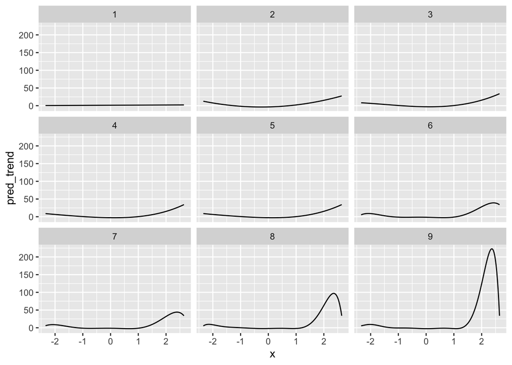

```r
### add your code here
df_viz_all %>% ggplot(mapping = aes(x=x)) + geom_line(mapping = aes(y=pred_trend)) + facet_wrap(~poly_degree)
```

### 2i)

It might be difficult to see what’s going on within each facet. Let’s “zoom” the y-axis within each facet to give a better picture of the trend associated with each model.

**Repeat the visualization from the previous problem, but this time set `scales = 'free_y'` within the `facet_wrap()` function.**

#### SOLUTION

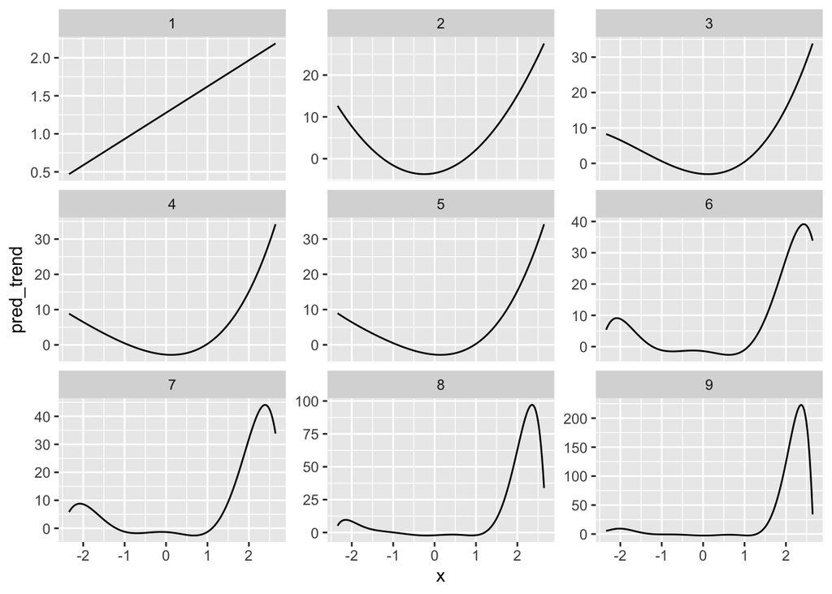

```r
### add your code here
df_viz_all %>% ggplot(mapping = aes(x=x)) + geom_line(mapping = aes(y=pred_trend)) + facet_wrap(~poly_degree, scales="free_y")
```

### 2j)

Lastly, let’s overlay the training set for additional context within each facet. To do so, you must override the `data` argument within the additional `geom_point()` layer, just as you did in Problem 2e).

**Repeat the visualization from the previous problem, however this time include `geom_point()` in between the “parent” `ggplot()` call and the `geom_line()` layer. You must override the `data` argument within this `geom_point()` layer by assigning `data` to `df_low_high`. You must map the `y` aesthetic directly within `geom_point()` to the `y` variable. Manually specify the marker `shape` to be `0` and the marker `color` to be `'red'` within `geom_point()`.**

#### SOLUTION

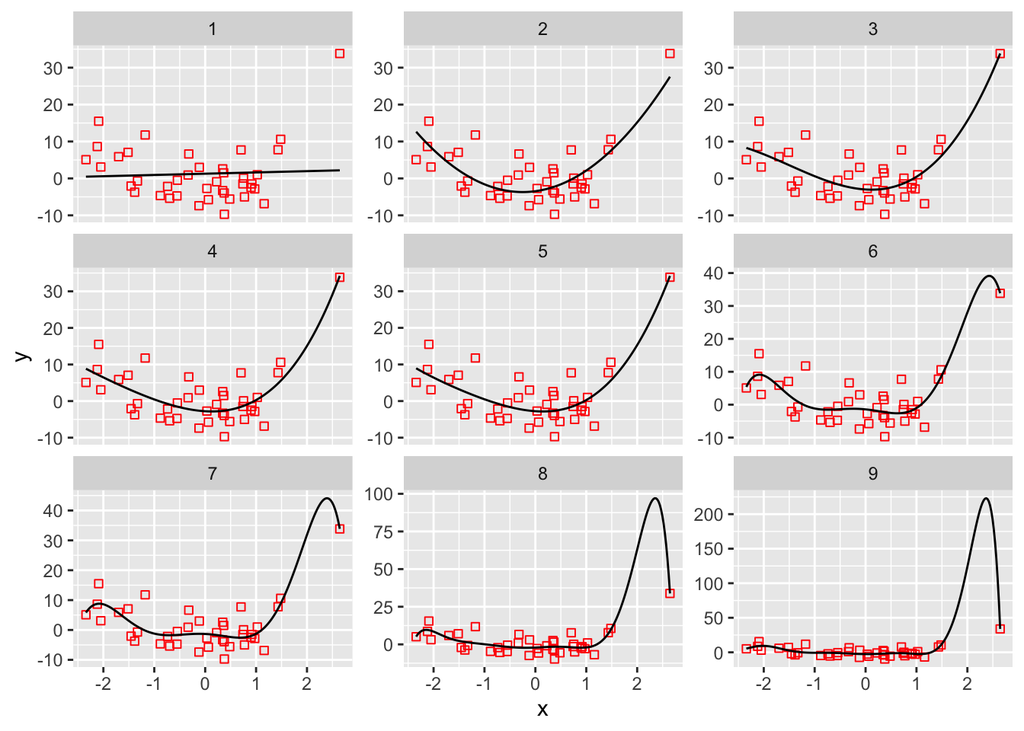

```r
### add your code here
df_viz_all %>% ggplot(mapping = aes(x=x)) + geom_point(data = df_low_high, mapping = aes(y=y), shape = 0, color = 'red') +geom_line(mapping = aes(y=pred_trend)) + facet_wrap(~poly_degree, scales="free_y")
```

### 2k)

**You previously used two performance metrics to identify the best model. How would you describe the predictive trends associated with the best performing model? Do the trends seem consistent with the training set?**

#### SOLUTION

What do you think?

## Problem 03

You previously selected the best model based on the **training set** alone. Your selection therefore did not consider how well the model will perform on new data! You will now try to identify the best model in hopes of finding one that *generalizes* to new data.

You will begin by creating a single training/test split. Sometimes this procedure is referred to as a training/validation split, but the motivation and goals are the same. You will randomly partition the data into a dedicated training set and dedicated hold-out set. You will train the models on the training set, and assess their performance on the hold-out set.

### 3a)

You will use an 80/20 train/test split. Thus, 80% of the data will be used for training the models and 20% of the data will be used to test the models. You will use the base R `sample()` function to create the vector of row indices that will serve as the training set.

The random seed is specified for you with the `set.seed()` function in the code chunk below. This ensures that the data splitting is **reproducible**. You will therefore get the same split every time you run the code chunk below. Please note, you must run the entire code chunk to ensure reproducibility.

**Complete the code chunk below. Use the `sample()` function to randomly sample 80% of the rows from the `df_low_high` data set. The `sample()` function randomly selects elements from a provided vector. You must therefore provide a vector that starts at 1 and ends at the number of rows in `df_low_high`. The result of `sample()` must be assigned to the `id_train` variable.**

**You must then use `id_train` to slice the training set from `df_low_high` and slice all except the `id_train` indices to create the hold-out test set. The training set is `df_train` and the hold-out test set is `df_holdout` in the code chunk below.**

#### SOLUTION

```r
set.seed(202214)
id_train <- sample(1:nrow(df_low_high), size = floor(0.8 * nrow(df_low_high)))

df_train <- df_low_high %>% slice(id_train)
df_holdout <- df_low_high %>% slice(-id_train)

df_train
```

```
## # A tibble: 32 × 2
##          x       y
##      <dbl>   <dbl>
##  1 -0.122  -7.40
##  2  0.344   2.59
##  3  1.48   10.6
##  4 -2.05    3.09
##  5 -2.34    5.08
##  6 -1.70    5.89
##  7 -1.52    7.07
##  8 -1.39   -3.74
##  9  0.0633 -5.76
## 10  0.754   0.0799
## # … with 22 more rows
```

```r
df_holdout
```

```
## # A tibble: 8 × 2
##        x     y
##    <dbl> <dbl>
## 1 -0.115  3.00
## 2  0.374 -3.94
## 3  0.704  7.72
## 4  0.772 -5.01
## 5  0.364  1.51
## 6 -1.46  -2.07
## 7  2.64  33.8
## 8 -0.322  6.62
```

### 3b)

Let’s visualize the data split so we know which observations were selected for training and which observations were selected for testing.

**Create a scatter plot using `ggplot2` which visualizes the relationship between the output `y` and the input `x`. You must use the marker color and marker shape to denote the training set from the hold-out test set.**

**There are multiple ways this figure can be created. It is up to you to make it, but you must create the figure using `ggplot2`. Use this as an opportunity to test out your understanding of the elements of the `ggplot2` philosophy for creating statistical visualizations.**

#### SOLUTION

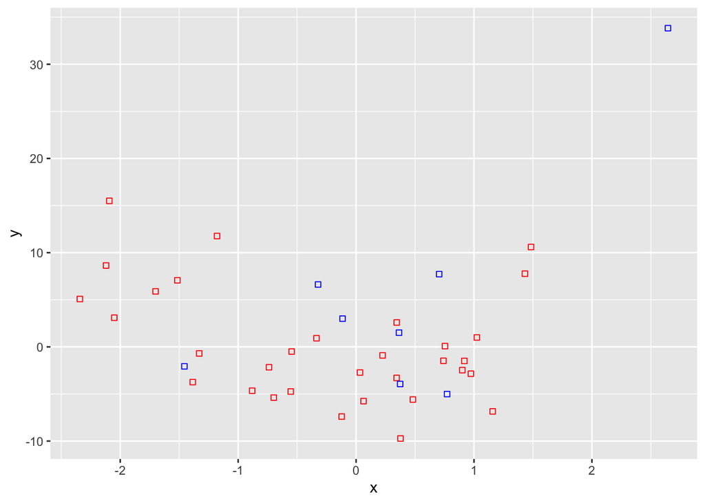

```r
### add your code here
df_train %>% ggplot(mapping = aes(x=x, y=y)) + geom_point(mapping = aes(y=y), shape = 0, color = 'red') + geom_point(data = df_holdout, mapping = aes(y=y), shape = 0, color = 'blue')
```

### 3c)

You will now fit the 9 polynomials using the training split. You **must NOT** use the complete original data set. You must fit the models using the randomly generated training split.

**You must use the `lm()` function, type in the correct formula, and assign the correct data set to the `data` argument of the `lm()` function. Again, this is tedious for now, but it is a learning experience!**

**The comments and variable names state which model should be specified in each code chunk.**

#### SOLUTION

```r
### linear relationship (degree 1)
fit_train_1 <-lm(y ~ x, data = df_train)
summary(fit_train_1)
```

```
##
## Call:
## lm(formula = y ~ x, data = df_train)
##
## Residuals:
##     Min      1Q  Median      3Q     Max
## -8.7369 -4.3709 -0.5283  2.9727 13.7140
##
## Coefficients:
##             Estimate Std. Error t value Pr(>|t|)
## (Intercept)  -0.2641     1.0453  -0.253   0.8022
## x            -1.9210     0.9081  -2.115   0.0428 *
## ---
## Signif. codes:  0 '***' 0.001 '**' 0.01 '*' 0.05 '.' 0.1 ' ' 1
##
## Residual standard error: 5.759 on 30 degrees of freedom
## Multiple R-squared:  0.1298, Adjusted R-squared:  0.1008
## F-statistic: 4.475 on 1 and 30 DF,  p-value: 0.04281
```

```r
### quadratic relationship (degree 2)
fit_train_2 <-lm(y ~ x + I(x^2), data = df_train)
summary(fit_train_2)
```

```
##
## Call:
## lm(formula = y ~ x + I(x^2), data = df_train)
##
## Residuals:
##    Min     1Q Median     3Q    Max
## -8.029 -2.804 -0.166  2.473 11.906
##
## Coefficients:
##             Estimate Std. Error t value Pr(>|t|)
## (Intercept)  -3.6401     1.1451  -3.179 0.003502 **
## x             0.6271     0.9354   0.670 0.507912
## I(x^2)        3.0492     0.7110   4.289 0.000182 ***
## ---
## Signif. codes:  0 '***' 0.001 '**' 0.01 '*' 0.05 '.' 0.1 ' ' 1
##
## Residual standard error: 4.582 on 29 degrees of freedom
## Multiple R-squared:  0.4675, Adjusted R-squared:  0.4308
## F-statistic: 12.73 on 2 and 29 DF,  p-value: 0.0001075
```

```r
### cubic relationship (degree 3)
fit_train_3 <-lm(y ~ x + I(x^2) + I(x^3), data = df_train)
summary(fit_train_3)
```

```
##
## Call:
## lm(formula = y ~ x + I(x^2) + I(x^3), data = df_train)
##
## Residuals:
##     Min      1Q  Median      3Q     Max
## -8.5308 -3.1725  0.1053  2.1412 10.0012
##
## Coefficients:
##             Estimate Std. Error t value Pr(>|t|)
## (Intercept)  -4.5265     1.1925  -3.796 0.000725 ***
## x            -1.6723     1.5079  -1.109 0.276834
## I(x^2)        4.6005     1.0646   4.321 0.000177 ***
## I(x^3)        1.2670     0.6682   1.896 0.068303 .
## ---
## Signif. codes:  0 '***' 0.001 '**' 0.01 '*' 0.05 '.' 0.1 ' ' 1
##
## Residual standard error: 4.39 on 28 degrees of freedom
## Multiple R-squared:  0.5281, Adjusted R-squared:  0.4776
## F-statistic: 10.45 on 3 and 28 DF,  p-value: 8.797e-05
```

```r
### degree 4
fit_train_4 <-lm(y ~ x + I(x^2) + I(x^3) + I(x^4), data = df_train)
summary(fit_train_4)
```

```
##
## Call:
## lm(formula = y ~ x + I(x^2) + I(x^3) + I(x^4), data = df_train)
##
## Residuals:
##     Min      1Q  Median      3Q     Max
## -8.4448 -3.3208  0.2984  2.0604 10.0741
##
## Coefficients:
##             Estimate Std. Error t value Pr(>|t|)
## (Intercept)  -4.4066     1.3734  -3.209  0.00343 **
## x            -1.9498     2.1372  -0.912  0.36969
## I(x^2)        4.2820     2.0223   2.117  0.04358 *
## I(x^3)        1.4664     1.2674   1.157  0.25739
## I(x^4)        0.1293     0.6931   0.187  0.85344
## ---
## Signif. codes:  0 '***' 0.001 '**' 0.01 '*' 0.05 '.' 0.1 ' ' 1
##
## Residual standard error: 4.468 on 27 degrees of freedom
## Multiple R-squared:  0.5287, Adjusted R-squared:  0.4589
## F-statistic: 7.573 on 4 and 27 DF,  p-value: 0.000316
```

```r
### degree 5
fit_train_5 <-lm(y ~ x + I(x^2) + I(x^3) + I(x^4) + I(x^5), data = df_train)
summary(fit_train_5)
```

```
##
## Call:
## lm(formula = y ~ x + I(x^2) + I(x^3) + I(x^4) + I(x^5), data = df_train)
##
## Residuals:
##    Min     1Q Median     3Q    Max
## -6.841 -2.593  0.096  2.386 11.214
##
## Coefficients:
##             Estimate Std. Error t value Pr(>|t|)
## (Intercept) -3.22294    1.50974  -2.135   0.0424 *
## x            0.08626    2.40684   0.036   0.9717
## I(x^2)      -0.59483    3.53117  -0.168   0.8675
## I(x^3)      -1.69332    2.26506  -0.748   0.4614
## I(x^4)       2.32700    1.48439   1.568   0.1291
## I(x^5)       1.12799    0.67943   1.660   0.1089
## ---
## Signif. codes:  0 '***' 0.001 '**' 0.01 '*' 0.05 '.' 0.1 ' ' 1
##
## Residual standard error: 4.329 on 26 degrees of freedom
## Multiple R-squared:  0.5739, Adjusted R-squared:  0.492
## F-statistic: 7.004 on 5 and 26 DF,  p-value: 0.0002903
```

```r
### degree 6
fit_train_6 <-lm(y ~ x + I(x^2) + I(x^3) + I(x^4) + I(x^5) + I(x^6), data = df_train)
summary(fit_train_6)
```

```
##
## Call:
## lm(formula = y ~ x + I(x^2) + I(x^3) + I(x^4) + I(x^5) + I(x^6),
##     data = df_train)
##
## Residuals:
##     Min      1Q  Median      3Q     Max
## -6.9916 -2.5474  0.3007  2.1968 10.8563
##
## Coefficients:
##             Estimate Std. Error t value Pr(>|t|)
## (Intercept) -3.32492    1.55353  -2.140   0.0423 *
## x            1.31739    3.82682   0.344   0.7335
## I(x^2)      -0.03174    3.83273  -0.008   0.9935
## I(x^3)      -3.88739    5.72797  -0.679   0.5036
## I(x^4)       1.51126    2.46546   0.613   0.5454
## I(x^5)       1.87140    1.90661   0.982   0.3357
## I(x^6)       0.29893    0.71461   0.418   0.6793
## ---
## Signif. codes:  0 '***' 0.001 '**' 0.01 '*' 0.05 '.' 0.1 ' ' 1
##
## Residual standard error: 4.399 on 25 degrees of freedom
## Multiple R-squared:  0.5769, Adjusted R-squared:  0.4753
## F-statistic:  5.68 on 6 and 25 DF,  p-value: 0.0007778
```

```r
### degree 7
fit_train_7 <-lm(y ~ x + I(x^2) + I(x^3) + I(x^4) + I(x^5) + I(x^6) + I(x^7), data = df_train)
summary(fit_train_7)
```

```
##
## Call:
## lm(formula = y ~ x + I(x^2) + I(x^3) + I(x^4) + I(x^5) + I(x^6) +
##     I(x^7), data = df_train)
##
## Residuals:
##     Min      1Q  Median      3Q     Max
## -7.0041 -2.7901 -0.2582  2.0576 10.3945
##
## Coefficients:
##             Estimate Std. Error t value Pr(>|t|)
## (Intercept)  -4.5145     1.8573  -2.431   0.0229 *
## x             2.5107     3.9408   0.637   0.5301
## I(x^2)        9.1462     8.8329   1.035   0.3108
## I(x^3)       -5.1702     5.7990  -0.892   0.3815
## I(x^4)       -9.2611     9.6697  -0.958   0.3477
## I(x^5)        0.2738     2.3480   0.117   0.9082
## I(x^6)        3.4202     2.8018   1.221   0.2341
## I(x^7)        0.9505     0.8254   1.152   0.2608
## ---
## Signif. codes:  0 '***' 0.001 '**' 0.01 '*' 0.05 '.' 0.1 ' ' 1
##
## Residual standard error: 4.371 on 24 degrees of freedom
## Multiple R-squared:  0.599,  Adjusted R-squared:  0.4821
## F-statistic: 5.122 on 7 and 24 DF,  p-value: 0.001149
```

```r
### degree 8
fit_train_8 <-lm(y ~ x + I(x^2) + I(x^3) + I(x^4) + I(x^5) + I(x^6) + I(x^7) + I(x^8), data = df_train)
summary(fit_train_8)
```

```
##
## Call:
## lm(formula = y ~ x + I(x^2) + I(x^3) + I(x^4) + I(x^5) + I(x^6) +
##     I(x^7) + I(x^8), data = df_train)
##
## Residuals:
##     Min      1Q  Median      3Q     Max
## -6.8445 -2.8350 -0.3728  1.8879 10.7489
##
## Coefficients:
##             Estimate Std. Error t value Pr(>|t|)
## (Intercept)  -4.5050     1.8947  -2.378   0.0261 *
## x             1.4589     5.6487   0.258   0.7985
## I(x^2)        9.5391     9.1302   1.045   0.3070
## I(x^3)       -1.3436    15.6049  -0.086   0.9321
## I(x^4)       -9.5915     9.9412  -0.965   0.3447
## I(x^5)       -3.1944    13.3052  -0.240   0.8124
## I(x^6)        2.9423     3.3792   0.871   0.3929
## I(x^7)        1.8408     3.4636   0.531   0.6002
## I(x^8)        0.2576     0.9721   0.265   0.7934
## ---
## Signif. codes:  0 '***' 0.001 '**' 0.01 '*' 0.05 '.' 0.1 ' ' 1
##
## Residual standard error: 4.458 on 23 degrees of freedom
## Multiple R-squared:  0.6002, Adjusted R-squared:  0.4612
## F-statistic: 4.317 on 8 and 23 DF,  p-value: 0.002733
```

```r
### degree 9
fit_train_9 <-lm(y ~ x + I(x^2) + I(x^3) + I(x^4) + I(x^5) + I(x^6) + I(x^7) + I(x^8) + I(x^9), data = df_train)
summary(fit_train_9)
```

```
##
## Call:
## lm(formula = y ~ x + I(x^2) + I(x^3) + I(x^4) + I(x^5) + I(x^6) +
##     I(x^7) + I(x^8) + I(x^9), data = df_train)
##
## Residuals:
##     Min      1Q  Median      3Q     Max
## -7.0085 -2.5977  0.0236  2.7546 10.0209
##
## Coefficients:
##             Estimate Std. Error t value Pr(>|t|)
## (Intercept)  -3.6809     2.1612  -1.703    0.103
## x            -0.4042     6.1349  -0.066    0.948
## I(x^2)        0.1165    14.7964   0.008    0.994
## I(x^3)        4.7807    17.4327   0.274    0.786
## I(x^4)       10.3328    26.4743   0.390    0.700
## I(x^5)       -6.7692    14.1071  -0.480    0.636
## I(x^6)      -11.3657    17.9251  -0.634    0.533
## I(x^7)        0.4932     3.8631   0.128    0.900
## I(x^8)        3.5204     4.1310   0.852    0.403
## I(x^9)        0.8677     1.0672   0.813    0.425
##
## Residual standard error: 4.491 on 22 degrees of freedom
## Multiple R-squared:  0.6119, Adjusted R-squared:  0.4531
## F-statistic: 3.854 on 9 and 22 DF,  p-value: 0.004702
```

### 3d)

You fit 9 models on the training split, it is now time to assess their performance on the dedicated **hold-out** test split! You are therefore evaluating the models on data **not** used for estimating their coefficients!

**Calculate the hold-out set RMSE for each model. It is up to you as to how to organize the RMSE values and display the results. Bare minimum, you must display the RMSE for each model. You are only allowed to use functions from lecture.**

#### SOLUTION

```r
### add as many code chunks as you feel are necessary
modelr::rmse(fit_train_1,df_holdout)
```

```
## [1] 14.64953
```

```r
modelr::rmse(fit_train_2,df_holdout)
```

```
## [1] 7.877605
```

```r
modelr::rmse(fit_train_3,df_holdout)
```

```
## [1] 7.994202
```

```r
modelr::rmse(fit_train_4,df_holdout)
```

```
## [1] 9.623962
```

```r
modelr::rmse(fit_train_5,df_holdout)
```

```
## [1] 66.52861
```

```r
modelr::rmse(fit_train_6,df_holdout)
```

```
## [1] 110.5928
```

```r
modelr::rmse(fit_train_7,df_holdout)
```

```
## [1] 547.3029
```

```r
modelr::rmse(fit_train_8,df_holdout)
```

```
## [1] 852.5923
```

```r
modelr::rmse(fit_train_9,df_holdout)
```

```
## [1] 3585.753
```

### 3e)

**Which model is the best according to the hold-out evaluation? Is it the same model as identified from the training set performance? How does the hold-out set rank the model identified as the best according to the training set?**

according to holdout evaluation model2 is the best performing model as its rmse value is the least. It is not the same model. It was model9 before. It identifies it as the worst model as the rmse value is the highest.

#### SOLUTION

What do you think?

### 3f)

The models named `fit_lm_*` were trained on the entire data set, while the models named `fit_train_*` were trained on the random training split. Although the training sizes are different, let’s try to get some idea on the sensitivity of the coefficients to the data.

You must use the `coefplot::multiplot()` function to compare the coefficients based on the original data and based on the training split data. You will compare the same model, but the data used for estimating the coefficients are different.

**Compare the coefficient summaries using `coefplot::multiplot()` for the model that was considered to be the best based on the training set.**

**How do the coefficients compare between the two slightly different training sets?**

#### SOLUTION

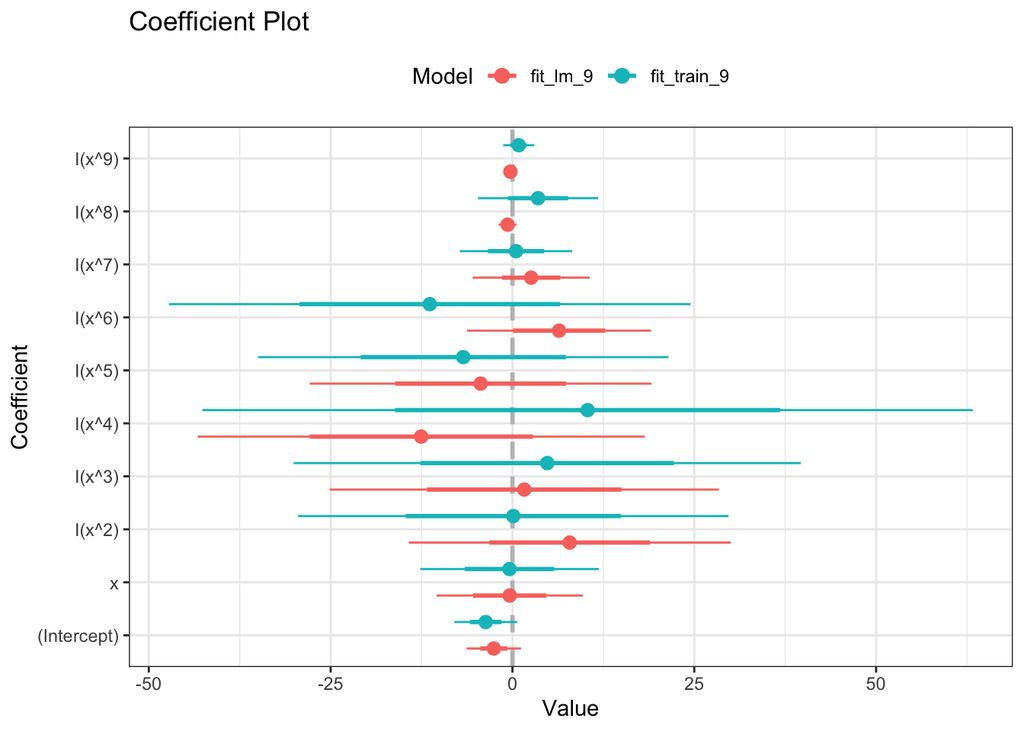

```r
### add your code here
coefplot::multiplot(fit_lm_9, fit_train_9) +
theme_bw() +
theme(legend.position = 'top')
```

What do you think?

### 3g)

**Compare the coefficient summaries using `coefplot::multiplot()` for the model that was considered to be the best based on the train/test split evaluation.**

#### SOLUTION

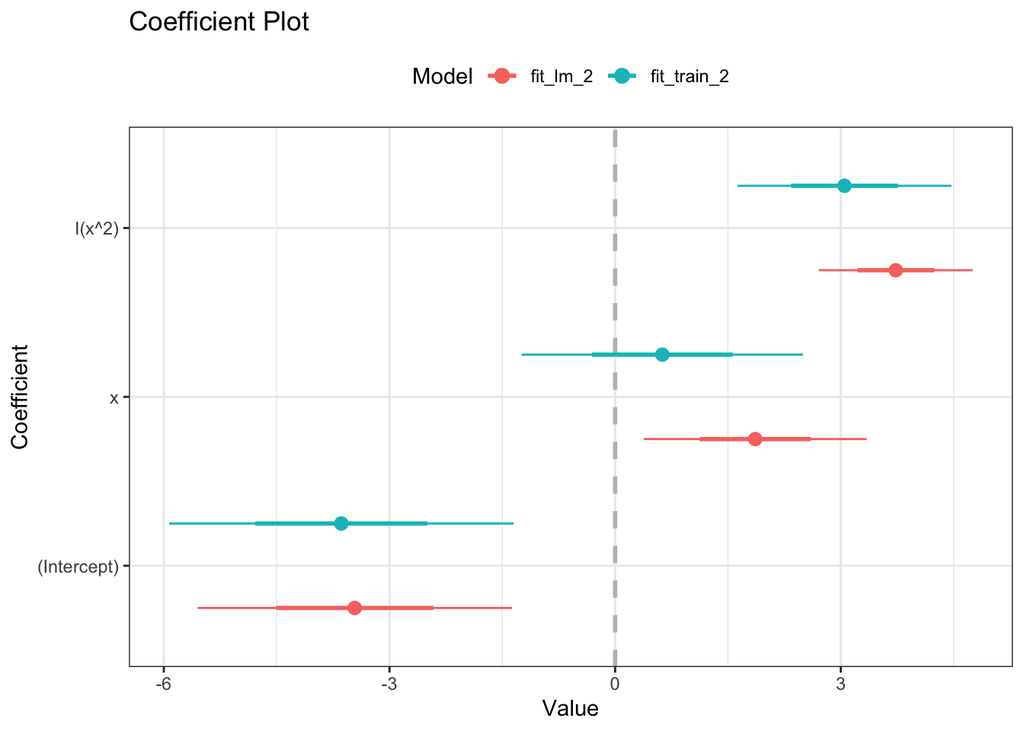

```r
### add your code here
coefplot::multiplot(fit_lm_2, fit_train_2) +
theme_bw() +
theme(legend.position = 'top')
```

What do you think?

## Problem 04

You have fit the 9 polynomials and assessed their performance multiple ways. It’s time to now use **resampling** to understand the reliability of your performance assessments. You will specifically use the `caret` package to manage all aspects of data splitting, training, and evaluating the models. If you do not have the `caret` package downloaded and installed please do so before proceeding. You only need to download and install `caret` once.

### 4a)

**Load the `caret` library into the environment with the `library()` function.**

#### SOLUTION

```r
### add your code here
library(caret)
```

### 4b)

The resampling scheme is specified by the `trainControl()` function in `caret`. The type of scheme is controlled by the `method` argument. For k-fold cross-validation, the `method` argument must equal `'cv'` and the number of folds is controlled by the `number` argument. We could instruct `caret` to use repeated cross-validation by specifying `method` to be `'repeatedcv'` and including the number of repeats via the `repeates` argument. However, we will follow the process consistent with lecture and use 5-fold cross-validation for this assignment.

**Specify the resampling scheme by completing the code chunk below. Assign the result of the `trainControl()` function to the `my_ctrl` variable.**

**How many times will a model be trained and tested using the desired resampling scheme?**  
For each model it is trained using cross validation 5 times i.e it’ll train and test on 5 different splits of the dataset and the whole process is repeated 3 times. Hence every model will be evaluated 15 times.

#### SOLUTION

```r
my_ctrl <-  trainControl(method = "repeatedcv", number = 5, repeats = 3)
```

How many times will an individual model be trained and tested?

### 4c)

The `caret` package requires that we specify a primary performance metric of interest, even though it will calculate several performance metrics for us. Please remember that the response is a continuous variable.

**You must select a primary performance metric to use to compare the models. Specify an appropriate metric to use for this modeling task. Choices must be written as a string and assigned to the `my_metric` variable. Possible choices are “Accuracy”, “RMSE”, “Kappa”, “Rsquared”, “MAE”, “ROC”. Why did you make the the choice that you did?**

*NOTE*: Not all of the listed performance metrics above are relevant to regression problems!

```r
my_metric <- "RMSE"
```

Why did you make your choice?  
I used RMSE because it tells how accurate our predictions are, basically it quantifies the amount of deviation from the actual values.

### 4d)

You will now go through training and evaluating the 9 polynomial models with the `train()` function from `caret`. You will use the formula interface to specify the model relationship. You must fit a linear (first order polynomial), quadratic (second order polynomial), cubic (third order polynomial), and so on up to and including a 9th order polynomial just as you did before. The difference is that you are not calling the `lm()` function directly. Instead, the `caret` package will manage the fitting process for you.

Please note that you will use the entire data set for training and evaluating with resampling. The `caret` package will manage the data splitting for you.

**You must specify the `method` argument in the `train()` function to be `"lm"`. You must specify the `metric` argument to be `my_metric` that you selected in Problem 4c). You must specify the `trControl` argument to be `my_ctrl` that you specified in Problem 4b). Don’t forget to set the `data` argument to be `df_low_high`!**

**The variable names below and comments are used to tell you which polynomial order you should assign to which object.**

*NOTE*: The models are trained in separate code chunks that way you can run each model apart from the others. The `caret` object is displayed to the screen for you within each code chunk. This will make it obvious when each model completes the resampling process.

#### SOLUTION

```r
### linear relationship (degree 1)
set.seed(2001)
mod_lowhigh_1 <- train(y~x, method = 'lm', metric = my_metric, trControl = my_ctrl, data = df_low_high)

mod_lowhigh_1
```

```
## Linear Regression
##
## 40 samples
##  1 predictor
##
## No pre-processing
## Resampling: Cross-Validated (5 fold, repeated 3 times)
## Summary of sample sizes: 32, 32, 32, 32, 32, 32, ...
## Resampling results:
##
##   RMSE      Rsquared   MAE
##   7.918694  0.2214787  5.977951
##
## Tuning parameter 'intercept' was held constant at a value of TRUE
```

```r
### quadratic relationship (degree 2)
set.seed(2001)
mod_lowhigh_2 <- train(y~x+I(x^2), method = 'lm', metric = my_metric, trControl = my_ctrl, data = df_low_high)

mod_lowhigh_2
```

```
## Linear Regression
##
## 40 samples
##  1 predictor
##
## No pre-processing
## Resampling: Cross-Validated (5 fold, repeated 3 times)
## Summary of sample sizes: 32, 32, 32, 32, 32, 32, ...
## Resampling results:
##
##   RMSE      Rsquared  MAE
##   5.796131  0.47929   4.626656
##
## Tuning parameter 'intercept' was held constant at a value of TRUE
```

```r
### cubic relationship (degree 3)
set.seed(2001)
mod_lowhigh_3 <- train(y~x+I(x^2)+I(x^3), method = 'lm', metric = my_metric, trControl = my_ctrl, data = df_low_high)

mod_lowhigh_3
```

```
## Linear Regression
##
## 40 samples
##  1 predictor
##
## No pre-processing
## Resampling: Cross-Validated (5 fold, repeated 3 times)
## Summary of sample sizes: 32, 32, 32, 32, 32, 32, ...
## Resampling results:
##
##   RMSE      Rsquared   MAE
##   5.219054  0.4597478  4.295198
##
## Tuning parameter 'intercept' was held constant at a value of TRUE
```

```r
### degree 4
set.seed(2001)
mod_lowhigh_4 <- train(y~x+I(x^2)+I(x^3) + I(x^4), method = 'lm', metric = my_metric, trControl = my_ctrl, data = df_low_high)

mod_lowhigh_4
```

```
## Linear Regression
##
## 40 samples
##  1 predictor
##
## No pre-processing
## Resampling: Cross-Validated (5 fold, repeated 3 times)
## Summary of sample sizes: 32, 32, 32, 32, 32, 32, ...
## Resampling results:
##
##   RMSE      Rsquared   MAE
##   7.598103  0.4452087  5.425402
##
## Tuning parameter 'intercept' was held constant at a value of TRUE
```

```r
### degree 5
set.seed(2001)
mod_lowhigh_5 <- train(y~x+I(x^2)+I(x^3) + I(x^4) + I(x^5), method = 'lm', metric = my_metric, trControl = my_ctrl, data = df_low_high)

mod_lowhigh_5
```

```
## Linear Regression
##
## 40 samples
##  1 predictor
##
## No pre-processing
## Resampling: Cross-Validated (5 fold, repeated 3 times)
## Summary of sample sizes: 32, 32, 32, 32, 32, 32, ...
## Resampling results:
##
##   RMSE      Rsquared   MAE
##   18.12798  0.3990298  9.234332
##
## Tuning parameter 'intercept' was held constant at a value of TRUE
```

```r
### degree 6
set.seed(2001)
mod_lowhigh_6 <- train(y~x+I(x^2)+I(x^3) + I(x^4) + I(x^5) + I(x^6), method = 'lm', metric = my_metric, trControl = my_ctrl, data = df_low_high)

mod_lowhigh_6
```

```
## Linear Regression
##
## 40 samples
##  1 predictor
##
## No pre-processing
## Resampling: Cross-Validated (5 fold, repeated 3 times)
## Summary of sample sizes: 32, 32, 32, 32, 32, 32, ...
## Resampling results:
##
##   RMSE      Rsquared   MAE
##   21.94083  0.4706872  10.36702
##
## Tuning parameter 'intercept' was held constant at a value of TRUE
```

```r
### degree 7
set.seed(2001)
mod_lowhigh_7 <- train(y~x+I(x^2)+I(x^3) + I(x^4) + I(x^5) + I(x^6) + I(x^7), method = 'lm', metric = my_metric, trControl = my_ctrl, data = df_low_high)

mod_lowhigh_7
```

```
## Linear Regression
##
## 40 samples
##  1 predictor
##
## No pre-processing
## Resampling: Cross-Validated (5 fold, repeated 3 times)
## Summary of sample sizes: 32, 32, 32, 32, 32, 32, ...
## Resampling results:
##
##   RMSE      Rsquared   MAE
##   120.8524  0.4167462  45.76435
##
## Tuning parameter 'intercept' was held constant at a value of TRUE
```

```r
### degree 8
set.seed(2001)
mod_lowhigh_8 <- train(y~x+I(x^2)+I(x^3) + I(x^4) + I(x^5) + I(x^6) + I(x^7) + I(x^8), method = 'lm', metric = my_metric, trControl = my_ctrl, data = df_low_high)

mod_lowhigh_8
```

```
## Linear Regression
##
## 40 samples
##  1 predictor
##
## No pre-processing
## Resampling: Cross-Validated (5 fold, repeated 3 times)
## Summary of sample sizes: 32, 32, 32, 32, 32, 32, ...
## Resampling results:
##
##   RMSE      Rsquared   MAE
##   506.6692  0.4050742  182.5424
##
## Tuning parameter 'intercept' was held constant at a value of TRUE
```

```r
### degree 9
set.seed(2001)
mod_lowhigh_9 <- train(y~x+I(x^2)+I(x^3) + I(x^4) + I(x^5) + I(x^6) + I(x^7) + I(x^8) + I(x^9), method = 'lm', metric = my_metric, trControl = my_ctrl, data = df_low_high)

mod_lowhigh_9
```

```
## Linear Regression
##
## 40 samples
##  1 predictor
##
## No pre-processing
## Resampling: Cross-Validated (5 fold, repeated 3 times)
## Summary of sample sizes: 32, 32, 32, 32, 32, 32, ...
## Resampling results:
##
##   RMSE      Rsquared   MAE
##   911.7983  0.4070802  326.7853
##
## Tuning parameter 'intercept' was held constant at a value of TRUE
```

### 4e)

The code chunk below compiles all of the model training results for you. The `lowhigh_results` object can be used to compare the models through tables and visualizations.

```r
lowhigh_results = resamples(list(fit_01 = mod_lowhigh_1,
                                 fit_02 = mod_lowhigh_2,
                                 fit_03 = mod_lowhigh_3,
                                 fit_04 = mod_lowhigh_4,
                                 fit_05 = mod_lowhigh_5,
                                 fit_06 = mod_lowhigh_6,
                                 fit_07 = mod_lowhigh_7,
                                 fit_08 = mod_lowhigh_8,
                                 fit_09 = mod_lowhigh_9))
```

The `caret` package provides default summary and plot methods which rank the models based on their resampling hold-out results. The `summary()` function prints a table like object which summarizes the resampling results. The `dotplot()` function creates a dot plot with confidence intervals on the resampling performance metrics.

**You must display the summary table using the `summary()` function for the resampling results and visualize the resampling results using the `dotplot()` function. In both the `summary()` and `dotplot()` functions, you must specify the `metric` argument to be primary performance metric that you specified previously.**

**Which model is the best according to the resampling results?**

#### SOLUTION

```r
### summary for your performance metric
summary(lowhigh_results,metric=my_metric)
```

```
##
## Call:
## summary.resamples(object = lowhigh_results, metric = my_metric)
##
## Models: fit_01, fit_02, fit_03, fit_04, fit_05, fit_06, fit_07, fit_08, fit_09
## Number of resamples: 15
##
## RMSE
##            Min.  1st Qu.   Median       Mean   3rd Qu.        Max. NA's
## fit_01 4.813232 5.872133 6.056301   7.918694  7.907301   15.390140    0
## fit_02 3.422669 4.522447 5.580535   5.796131  6.903469    8.749774    0
## fit_03 3.074006 4.504340 5.076627   5.219054  6.122634    6.968109    0
## fit_04 3.123853 4.595064 5.693867   7.598103  6.335275   24.383783    0
## fit_05 3.146056 5.037930 6.007065  18.127979  9.827769   75.698504    0
## fit_06 2.686771 4.651081 5.706411  21.940831  8.021605   96.627181    0
## fit_07 2.681449 5.310018 5.932782 120.852404 13.299227  733.258080    0
## fit_08 3.003248 5.713835 5.950069 506.669201 12.095947 3821.374063    0
## fit_09 3.114982 5.561050 6.031269 911.798253 70.176591 8075.933684    0
```

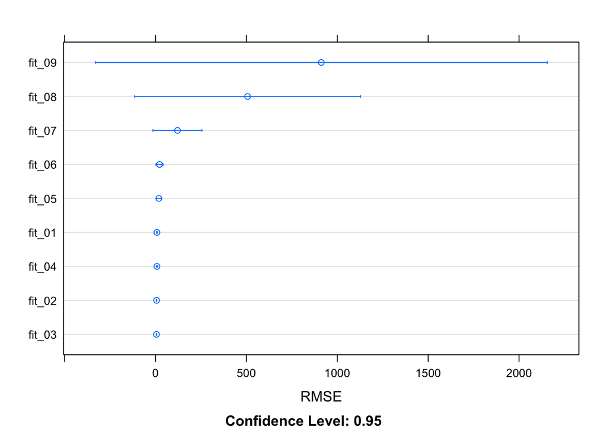

```r
### dotplot for your performance metric
dotplot(lowhigh_results, metric = "RMSE")
```

### 4f)

The `mod_lowhigh_*` variables are `caret` model objects and are essentially lists. Each object, `mod_lowhigh_1` through `mod_lowhigh_9` consists of numerous fields which can be accessed via the dollar sign operator, `$`. One such field, `$finalModel`, provides access to the underlying `lm()` model object associated with the **final fit**. Thus, even though `mod_lowhigh_1` is a `caret` object the field `mod_lowhigh_1$finalModel` is an `lm()` object just like the `fit_lm_1` object you fit at the beginning of the assignment. We can apply functions to help interpret the model behavior just as we did previously.

**You must compare the coefficients between the top 3 models identified by the resampling procedure using the `coefplot::multiplot()` function.**

**Are the coefficient estimates similar for those coefficients present in at least 2 of the models visualized in the previous figure?**  
The coefficient estimates are similar for coefficients of x for model 3 and 4.On the other hand, the coefficient of x for model2 is pretty different as compared to the rest of the models. Also the estimates vary a lot for the coefficients of x^2 for model4.

**Is the level or amount of uncertainty associated with the coefficients consistent across the three models?**

The level of uncertainty is more or less the same for the coefficient of x for model 3 and 4 (similar confidence intervals) but in general the intervals and hence the uncertainity varies.

#### SOLUTION

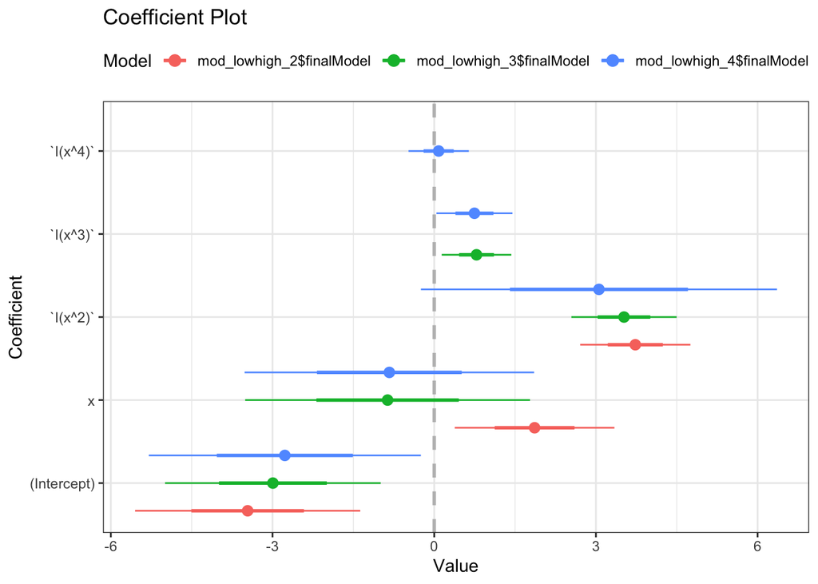

```r
### your code here
coefplot::multiplot(mod_lowhigh_2$finalModel, mod_lowhigh_3$finalModel, mod_lowhigh_4$finalModel) +
theme_bw() +
theme(legend.position = 'top')
```

What do you think?

## Problem 05

You have completed an entire regression problem! You correctly used resampling to train and compare simple to complex models in order to identify the most appropriate model that generalizes to new data!

However, let’s try and gain additional insight by repeating the resampling procedure on another data set. The data used in the previous problems were generated using a “high” level of noise. You will now train and compare the same 9 polynomial models, but with data coming from a “low” level of noise. The underlying **data generating process** is the same. All that changed is the noise level. We will learn what that means in more detail throughout this semester. For now, the main purpose is to compare what happens when you can train models under different noise levels.

The low noise level data are loaded in the code chunk below. The glimpse shows that the variable names are the same as those in the high noise level data from before.

```r
path_low_low <- 'hw02_lowsize_lownoise.csv'

df_low_low <- readr::read_csv(path_low_low, col_names = TRUE)
df_low_low %>% glimpse()
```

```
## Rows: 40
## Columns: 2
## $ x <dbl> -0.11464944, 0.22502931, 0.37356406, -2.34241739, 1.15847408, 0.3443…
## $ y <dbl> -1.1796816, -1.1355929, -1.1975801, 8.0392787, 0.7875834, -0.4632007…
```

### 5a)

#### SOLUTION

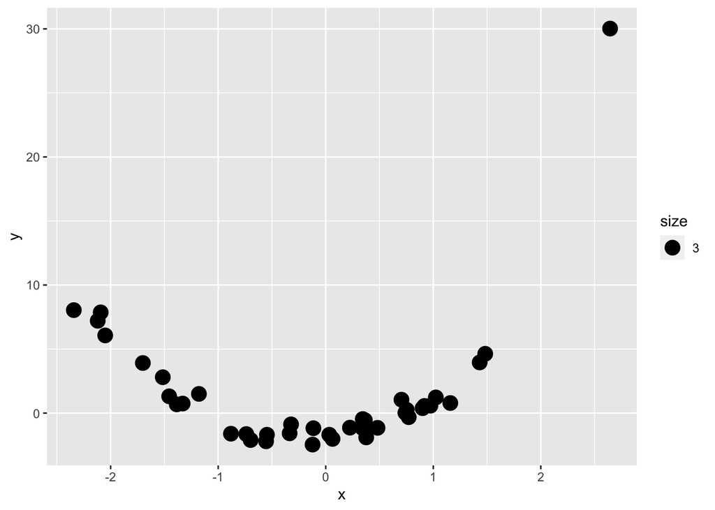

```r
### your code here
ggplot(data = df_low_low) +
  geom_point(mapping = aes(x = x, y = y, size = 3))
```

How does it compare?

### 5b)

You will not repeat all of the previous exercises. Instead, you will jump straight to training and evaluating models with resampling. You will use the same resampling scheme and primary performance metric that you used in Problem 04 to train the 9 polynomial models. This time however you will use the low noise level data.

**Train the 9 polynomial models using the required formula interface, `method`, `trControl`, and `metric` arguments that you used in Problem 04. However, pay close attention and set the `data` argument to be `df_low_low`.**

**The variable names and comments specify which polynomial to use.**

*NOTE*: again this is VERY tedious…we will see more efficient ways of going through such a process later in the semester.

#### SOLUTION

```r
### linear relationship (degree 1)
set.seed(2001)
mod_lowlow_1 <- train(y~x,data=df_low_low,method="lm",metric=my_metric,trControl=my_ctrl)

mod_lowlow_1
```

```
## Linear Regression
##
## 40 samples
##  1 predictor
##
## No pre-processing
## Resampling: Cross-Validated (5 fold, repeated 3 times)
## Summary of sample sizes: 32, 32, 32, 32, 32, 32, ...
## Resampling results:
##
##   RMSE      Rsquared  MAE
##   5.170625  0.270785  3.538185
##
## Tuning parameter 'intercept' was held constant at a value of TRUE
```

```r
### quadratic relationship (degree 2)
set.seed(2001)
mod_lowlow_2 <- train(y~x+I(x^2),data=df_low_low,method="lm",metric=my_metric,trControl=my_ctrl)

mod_lowlow_2
```

```
## Linear Regression
##
## 40 samples
##  1 predictor
##
## No pre-processing
## Resampling: Cross-Validated (5 fold, repeated 3 times)
## Summary of sample sizes: 32, 32, 32, 32, 32, 32, ...
## Resampling results:
##
##   RMSE      Rsquared   MAE
##   2.130456  0.9050013  1.343144
##
## Tuning parameter 'intercept' was held constant at a value of TRUE
```

```r
### cubic relationship (degree 3)
set.seed(2001)
mod_lowlow_3 <- train(y~x+I(x^2)+I(x^3),data=df_low_low,method="lm",metric=my_metric,trControl=my_ctrl)

mod_lowlow_3
```

```
## Linear Regression
##
## 40 samples
##  1 predictor
##
## No pre-processing
## Resampling: Cross-Validated (5 fold, repeated 3 times)
## Summary of sample sizes: 32, 32, 32, 32, 32, 32, ...
## Resampling results:
##
##   RMSE      Rsquared   MAE
##   1.865507  0.9214031  1.117858
##
## Tuning parameter 'intercept' was held constant at a value of TRUE
```

```r
### degree 4
set.seed(2001)
mod_lowlow_4 <- train(y~x+I(x^2)+I(x^3)+I(x^4),data=df_low_low,method="lm",metric=my_metric,trControl=my_ctrl)

mod_lowlow_4
```

```
## Linear Regression
##
## 40 samples
##  1 predictor
##
## No pre-processing
## Resampling: Cross-Validated (5 fold, repeated 3 times)
## Summary of sample sizes: 32, 32, 32, 32, 32, 32, ...
## Resampling results:
##
##   RMSE      Rsquared   MAE
##   1.938021  0.9259349  1.069514
##
## Tuning parameter 'intercept' was held constant at a value of TRUE
```

```r
### degree 5
set.seed(2001)
mod_lowlow_5 <- train(y~x+I(x^2)+I(x^3)+I(x^4)+I(x^5),data=df_low_low,method="lm",metric=my_metric,trControl=my_ctrl)

mod_lowlow_5
```

```
## Linear Regression
##
## 40 samples
##  1 predictor
##
## No pre-processing
## Resampling: Cross-Validated (5 fold, repeated 3 times)
## Summary of sample sizes: 32, 32, 32, 32, 32, 32, ...
## Resampling results:
##
##   RMSE      Rsquared   MAE
##   2.412691  0.9558501  1.209471
##
## Tuning parameter 'intercept' was held constant at a value of TRUE
```

```r
### degree 6
set.seed(2001)
mod_lowlow_6 <- train(y~x+I(x^2)+I(x^3)+I(x^4)+I(x^5)+I(x^6),data=df_low_low,method="lm",metric=my_metric,trControl=my_ctrl)

mod_lowlow_6
```

```
## Linear Regression
##
## 40 samples
##  1 predictor
##
## No pre-processing
## Resampling: Cross-Validated (5 fold, repeated 3 times)
## Summary of sample sizes: 32, 32, 32, 32, 32, 32, ...
## Resampling results:
##
##   RMSE      Rsquared   MAE
##   2.426334  0.9548965  1.180192
##
## Tuning parameter 'intercept' was held constant at a value of TRUE
```

```r
### degree 7
set.seed(2001)
mod_lowlow_7 <- train(y~x+I(x^2)+I(x^3)+I(x^4)+I(x^5)+I(x^6)+I(x^7),data=df_low_low,method="lm",metric=my_metric,trControl=my_ctrl)

mod_lowlow_7
```

```
## Linear Regression
##
## 40 samples
##  1 predictor
##
## No pre-processing
## Resampling: Cross-Validated (5 fold, repeated 3 times)
## Summary of sample sizes: 32, 32, 32, 32, 32, 32, ...
## Resampling results:
##
##   RMSE      Rsquared   MAE
##   11.96606  0.9399356  4.60443
##
## Tuning parameter 'intercept' was held constant at a value of TRUE
```

```r
### degree 8
set.seed(2001)
mod_lowlow_8 <- train(y~x+I(x^2)+I(x^3)+I(x^4)+I(x^5)+I(x^6)+I(x^7)+I(x^8),data=df_low_low,method="lm",metric=my_metric,trControl=my_ctrl)

mod_lowlow_8
```

```
## Linear Regression
##
## 40 samples
##  1 predictor
##
## No pre-processing
## Resampling: Cross-Validated (5 fold, repeated 3 times)
## Summary of sample sizes: 32, 32, 32, 32, 32, 32, ...
## Resampling results:
##
##   RMSE      Rsquared   MAE
##   44.23807  0.9274085  16.0339
##
## Tuning parameter 'intercept' was held constant at a value of TRUE
```

```r
### degree 9
set.seed(2001)
mod_lowlow_9 <- train(y~x+I(x^2)+I(x^3)+I(x^4)+I(x^5)+I(x^6)+I(x^7)+I(x^8)+I(x^9),data=df_low_low,method="lm",metric=my_metric,trControl=my_ctrl)

mod_lowlow_9
```

```
## Linear Regression
##
## 40 samples
##  1 predictor
##
## No pre-processing
## Resampling: Cross-Validated (5 fold, repeated 3 times)
## Summary of sample sizes: 32, 32, 32, 32, 32, 32, ...
## Resampling results:
##
##   RMSE     Rsquared   MAE
##   69.8481  0.9280973  25.07724
##
## Tuning parameter 'intercept' was held constant at a value of TRUE
```

### 5c)

The code chunk below compiles all of the resampling results together for the models associated with the low noise level data.

```r
lowlow_results = resamples(list(fit_01 = mod_lowlow_1,
                                fit_02 = mod_lowlow_2,
                                fit_03 = mod_lowlow_3,
                                fit_04 = mod_lowlow_4,
                                fit_05 = mod_lowlow_5,
                                fit_06 = mod_lowlow_6,
                                fit_07 = mod_lowlow_7,
                                fit_08 = mod_lowlow_8,
                                fit_09 = mod_lowlow_9))
```

As with the `lowhigh_results` object, you can now visualize summary statistics associated with the resampling results and identify the best performing models.

**You must display the summary table using the `summary()` function for the resampling results and visualize the resampling results using the `dotplot()` function. In both the `summary()` and `dotplot()` functions, you must specify the `metric` argument to be primary performance metric that you specified previously.**

**Which model is the best according to the resampling results?**  
model3 seems the best according to the resampling scheme as its mean rmse value is the lowest.

#### SOLUTION

```r
### print the resampling summary for the performance metric
summary(lowlow_results,metric=my_metric)
```

```
##
## Call:
## summary.resamples(object = lowlow_results, metric = my_metric)
##
## Models: fit_01, fit_02, fit_03, fit_04, fit_05, fit_06, fit_07, fit_08, fit_09
## Number of resamples: 15
##
## RMSE
##             Min.   1st Qu.    Median      Mean  3rd Qu.       Max. NA's
## fit_01 2.4338576 2.9410481 3.7831721  5.170625 4.875482  11.754307    0
## fit_02 0.7291411 1.3322759 1.5277661  2.130456 1.908937   5.068442    0
## fit_03 0.7701144 0.9094194 1.0461808  1.865507 1.236685   5.485828    0
## fit_04 0.5035745 0.7267412 0.9298068  1.938021 1.309384   7.013930    0
## fit_05 0.3396740 0.5937641 0.7044942  2.412691 1.026655  10.793134    0
## fit_06 0.2980080 0.4632557 0.6456859  2.426334 0.907115  22.792723    0
## fit_07 0.3019885 0.5775756 0.8248562 11.966060 2.316529  87.951850    0
## fit_08 0.3729307 0.5679059 0.8636217 44.238066 1.607014 247.752141    0
## fit_09 0.3473625 0.5692557 0.8596003 69.848098 3.828119 373.188750    0
```

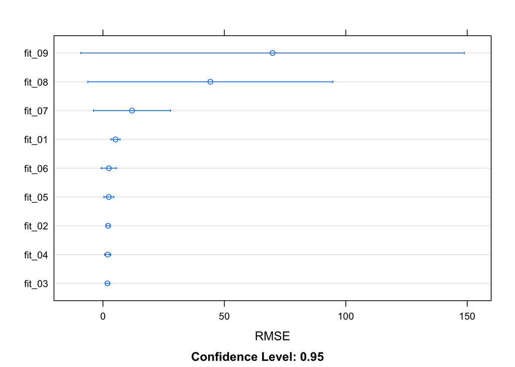

```r
### visualize the dotplot for the performance metric
dotplot(lowlow_results, metric = "RMSE")
```

Which model is the best?  
Model3 is the best.

### 5d)

The `df_low_high` and `df_low_low` data have the same sample size, but the data were generated under different uncontrollable noise levels. This exercise is analogous to recording measurements with worn out low fidelity sensors (`df_low_high`) compared to new modern high resolution sensors (`df_low_low`). The low level of noise gives a “better” glimpse of the real underlying **data generating process**.

**Did the resampling scheme identify the same model as the best model for the two noise cases? Did the models identified to be poor for the high noise case remain poor for the low noise case?**  
Yes the resampling scheme identified the same model as the best model for the two noise cases i.e model3. Yes, model 9 perfomed poorly in both cases.

#### SOLUTION

What do you think?

## Problem 06

You will repeat the resampling exercise with one more data set. This version of the data were generated under the high noise level, as with the first data set you worked with. However, this version of the data has more observations. Thus, you are still working with noisy data, but you now have a higher sample size to work with. This problem therefore focuses on the influence of sample size on the modeling effort.

The high sample size high noise level data are loaded in the code chunk below. The glimpse shows that the variable names are the same as those in the previous two cases.

```r
path_high_high <- 'hw02_highsize_highnoise.csv'

df_high_high <- readr::read_csv(path_high_high, col_names = TRUE)
df_high_high %>% glimpse()
```

```
## Rows: 200
## Columns: 2
## $ x <dbl> -0.11464944, 0.22502931, 0.37356406, -2.34241739, 1.15847408, 0.3443…
## $ y <dbl> -2.56496089, 13.65865394, 0.09488574, 1.51679017, 1.30866543, 1.4072…
```

### 6a)

**Create a scatter plot between the input, `x`, and the response, `y`, for the high noise level data. How does this figure compare to the one you made in Problem 1a)?**  
The high noise data seems to give us a better picture about the trend of the data as compared to the figure in problem 1a). It has the points concentrated.

#### SOLUTION

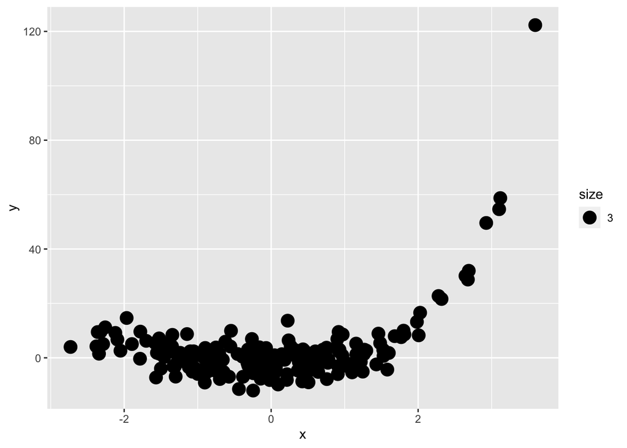

```r
### your code here
ggplot(data = df_high_high) +
  geom_point(mapping = aes(x = x, y = y, size = 3))
```

How does it compare?

### 6b)

You must execute resampling on the 9 polynomial models using the high sample size and high noise level data.

**Train the 9 polynomial models using the required formula interface, `method`, `trControl`, and `metric` arguments that you used in Problem 04. However, pay close attention and set the `data` argument to be `df_high_high`.**

**The variable names and comments specify which polynomial to use.**

*NOTE*: again this is VERY tedious…we will see more efficient ways of going through such a process later in the semester.

#### SOLUTION

```r
### linear relationship (degree 1)
set.seed(2001)
mod_highhigh_1 <- train(y~x,data=df_high_high,method="lm",metric=my_metric,trControl=my_ctrl)

mod_highhigh_1
```

```
## Linear Regression
##
## 200 samples
##   1 predictor
##
## No pre-processing
## Resampling: Cross-Validated (5 fold, repeated 3 times)
## Summary of sample sizes: 160, 160, 160, 160, 160, 160, ...
## Resampling results:
##
##   RMSE      Rsquared  MAE
##   10.95886  0.182936  7.057703
##
## Tuning parameter 'intercept' was held constant at a value of TRUE
```

```r
### quadratic relationship (degree 2)
set.seed(2001)
mod_highhigh_2 <- train(y~x + I(x^2),data=df_high_high,method="lm",metric=my_metric,trControl=my_ctrl)

mod_highhigh_2
```

```
## Linear Regression
##
## 200 samples
##   1 predictor
##
## No pre-processing
## Resampling: Cross-Validated (5 fold, repeated 3 times)
## Summary of sample sizes: 160, 160, 160, 160, 160, 160, ...
## Resampling results:
##
##   RMSE      Rsquared   MAE
##   7.107754  0.6684591  4.824084
##
## Tuning parameter 'intercept' was held constant at a value of TRUE
```

```r
### cubic relationship (degree 3)
set.seed(2001)
mod_highhigh_3 <- train(y~x + I(x^2) + I(x^3),data=df_high_high,method="lm",metric=my_metric,trControl=my_ctrl)

mod_highhigh_3
```

```
## Linear Regression
##
## 200 samples
##   1 predictor
##
## No pre-processing
## Resampling: Cross-Validated (5 fold, repeated 3 times)
## Summary of sample sizes: 160, 160, 160, 160, 160, 160, ...
## Resampling results:
##
##   RMSE      Rsquared   MAE
##   5.733521  0.7196666  4.16518
##
## Tuning parameter 'intercept' was held constant at a value of TRUE
```

```r
### degree 4
set.seed(2001)
mod_highhigh_4 <- train(y~x + I(x^2) + I(x^3) + I(x^4),data=df_high_high,method="lm",metric=my_metric,trControl=my_ctrl)

mod_highhigh_4
```

```
## Linear Regression
##
## 200 samples
##   1 predictor
##
## No pre-processing
## Resampling: Cross-Validated (5 fold, repeated 3 times)
## Summary of sample sizes: 160, 160, 160, 160, 160, 160, ...
## Resampling results:
##
##   RMSE      Rsquared   MAE
##   5.018227  0.7377622  3.812338
##
## Tuning parameter 'intercept' was held constant at a value of TRUE
```

```r
### degree 5
set.seed(2001)
mod_highhigh_5 <- train(y~x + I(x^2) + I(x^3) + I(x^4) + I(x^5),data=df_high_high,method="lm",metric=my_metric,trControl=my_ctrl)

mod_highhigh_5
```

```
## Linear Regression
##
## 200 samples
##   1 predictor
##
## No pre-processing
## Resampling: Cross-Validated (5 fold, repeated 3 times)
## Summary of sample sizes: 160, 160, 160, 160, 160, 160, ...
## Resampling results:
##
##   RMSE    Rsquared  MAE
##   4.4315  0.759475  3.537482
##
## Tuning parameter 'intercept' was held constant at a value of TRUE
```

```r
### degree 6
set.seed(2001)
mod_highhigh_6 <- train(y~x + I(x^2) + I(x^3) + I(x^4) + I(x^5) + I(x^6),data=df_high_high,method="lm",metric=my_metric,trControl=my_ctrl)

mod_highhigh_6
```

```
## Linear Regression
##
## 200 samples
##   1 predictor
##
## No pre-processing
## Resampling: Cross-Validated (5 fold, repeated 3 times)
## Summary of sample sizes: 160, 160, 160, 160, 160, 160, ...
## Resampling results:
##
##   RMSE      Rsquared   MAE
##   4.896616  0.7547662  3.648192
##
## Tuning parameter 'intercept' was held constant at a value of TRUE
```

```r
### degree 7
set.seed(2001)
mod_highhigh_7 <- train(y~x + I(x^2) + I(x^3) + I(x^4) + I(x^5) + I(x^6) + I(x^7),data=df_high_high,method="lm",metric=my_metric,trControl=my_ctrl)

mod_highhigh_7
```

```
## Linear Regression
##
## 200 samples
##   1 predictor
##
## No pre-processing
## Resampling: Cross-Validated (5 fold, repeated 3 times)
## Summary of sample sizes: 160, 160, 160, 160, 160, 160, ...
## Resampling results:
##
##   RMSE      Rsquared   MAE
##   4.926256  0.7412829  3.658504
##
## Tuning parameter 'intercept' was held constant at a value of TRUE
```

```r
### degree 8
set.seed(2001)
mod_highhigh_8 <- train(y~x + I(x^2) + I(x^3) + I(x^4) + I(x^5) + I(x^6) + I(x^7) + I(x^8),data=df_high_high,method="lm",metric=my_metric,trControl=my_ctrl)

mod_highhigh_8
```

```
## Linear Regression
##
## 200 samples
##   1 predictor
##
## No pre-processing
## Resampling: Cross-Validated (5 fold, repeated 3 times)
## Summary of sample sizes: 160, 160, 160, 160, 160, 160, ...
## Resampling results:
##
##   RMSE      Rsquared   MAE
##   5.031024  0.7509565  3.684695
##
## Tuning parameter 'intercept' was held constant at a value of TRUE
```

```r
### degree 9
set.seed(2001)
mod_highhigh_9 <- train(y~x + I(x^2) + I(x^3) + I(x^4) + I(x^5) + I(x^6) + I(x^7) + I(x^8) + I(x^9),data=df_high_high,method="lm",metric=my_metric,trControl=my_ctrl)

mod_highhigh_9
```

```
## Linear Regression
##
## 200 samples
##   1 predictor
##
## No pre-processing
## Resampling: Cross-Validated (5 fold, repeated 3 times)
## Summary of sample sizes: 160, 160, 160, 160, 160, 160, ...
## Resampling results:
##
##   RMSE      Rsquared   MAE
##   7.987812  0.6968192  4.309836
##
## Tuning parameter 'intercept' was held constant at a value of TRUE
```

### 6c)

The code chunk below compiles all of the resampling results together for the models associated with the high sample size and high noise level data.

```r
highhigh_results = resamples(list(fit_01 = mod_highhigh_1,
                                  fit_02 = mod_highhigh_2,
                                  fit_03 = mod_highhigh_3,
                                  fit_04 = mod_highhigh_4,
                                  fit_05 = mod_highhigh_5,
                                  fit_06 = mod_highhigh_6,
                                  fit_07 = mod_highhigh_7,
                                  fit_08 = mod_highhigh_8,
                                  fit_09 = mod_highhigh_9))
highhigh_results
```

[output not shown]

As with the `lowhigh_results` object, you can now visualize summary statistics associated with the resampling results and identify the best performing models.

**You must display the summary table using the `summary()` function for the resampling results and visualize the resampling results using the `dotplot()` function. In both the `summary()` and `dotplot()` functions, you must specify the `metric` argument to be primary performance metric that you specified previously.**

**Which model is the best according to the resampling results?**  
model 5 is the best as it has the lowest rmse.

#### SOLUTION

```r
### print the resampling summary for the performance metric
summary(highhigh_results,metric=my_metric)
```

```
##
## Call:
## summary.resamples(object = highhigh_results, metric = my_metric)
##
## Models: fit_01, fit_02, fit_03, fit_04, fit_05, fit_06, fit_07, fit_08, fit_09
## Number of resamples: 15
##
## RMSE
##            Min.  1st Qu.   Median      Mean   3rd Qu.      Max. NA's
## fit_01 7.144399 8.264894 8.953933 10.958865 10.699515 22.135414    0
## fit_02 4.893204 5.541600 6.013430  7.107754  6.430030 13.932716    0
## fit_03 4.233114 4.515292 5.218235  5.733521  5.426128  9.685728    0
## fit_04 3.863631 4.371871 4.710784  5.018227  5.047915  7.204624    0
## fit_05 3.548950 3.974646 4.355893  4.431500  4.714398  5.869710    0
## fit_06 3.560619 4.071285 4.434506  4.896616  4.839592  7.759908    0
## fit_07 3.530708 4.325433 4.535044  4.926256  5.217821  7.436552    0
## fit_08 3.812083 4.289508 4.419846  5.031024  4.731341 12.141231    0
## fit_09 3.818716 4.292539 4.732182  7.987812  7.338374 37.521379    0
```

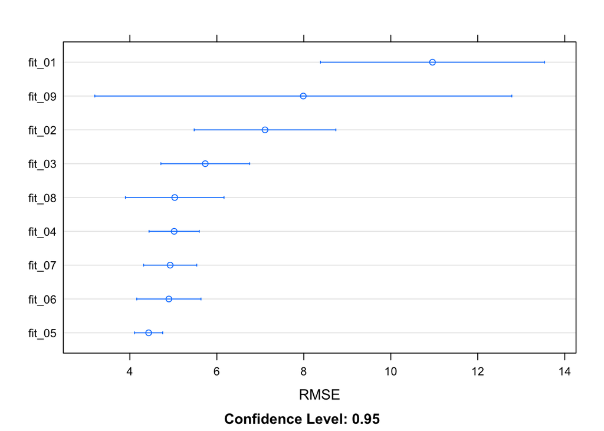

```r
### visualize the dotplot for the performance metric
dotplot(highhigh_results, metric = "RMSE")
```

Which model is the best?

### 6d)

The `df_low_high` and `df_high_high` data have the same noise level, but different sample sizes.

**Did the resampling scheme identify the same model as the best model for the two sample size cases? Did the models identified to be poor for the low sample size case remain poor for the high sample size case?**

#### SOLUTION

No, the best models identified are different, i.e model3 before and now model 5. Also, the poorest model was before model 9 and now it is model 1.

What do you think?

### 6e)

You have executed a model selection task under varying levels of noise and sample sizes. Your goal was to select the best model from a candidate set of varying levels of complexity.

**What do you think the impact is between sample size and noise level on the ability to identify complex behavior?**  
I observed that when we change the sample size, the best performing model changed. But it remained the same when we changed the noise level. It seems sample size has a higher influence on the complexity of the best model as compared to noise level.

#### SOLUTION

What do you think?